# Analysis code

The role of memory in counterfactual valuation

Natalie Biderman

02/16/2021

This is an analysis code for a study testing the role of memory in the inverse decision bias. The code loads preprocessed data from MTurk experiments, and analyses their results. Our analysis includes Bayesian regression models, some of which take several hours to run. Accordingly, here we only load the models which we already ran, but if you wish to run the models, you may define the parameter run_models to be equal to 1.  
In most of our models, we breakdown interaction terms and look at coefficients of interest as a function of different variables. In such cases, we present both the original model coefficients and the rearranged model coefficients. For more details, see Analysis section in the manuscript.

[figure not shown]

Figure1. Experimental design

## Setup and load data

```r
rm(list=ls(all=TRUE))

knitr::opts_chunk$set(echo = TRUE, message=FALSE, warning=FALSE)

# If packages are not installed, install. Then, load libraries.
list_of_packages <- c("ggplot2", "cowplot",  "tidyr", "dplyr", "rstanarm", "kableExtra", "stringr", "mosaic")
new_packages <- list_of_packages[!(list_of_packages %in% installed.packages()[,"Package"])]
if(length(new_packages)) install.packages(new_packages)
lapply(list_of_packages, require, character.only = TRUE)

# Load functions
source("Tools/plotting.R")

# Figure parameters
fig_size = c(10,10)
fig_type = "svg"  # "eps" # or png
n_sem <- 1
Save_plots <- 1
point_size <- 4.5
point_stroke <- 0.6
line_size <- 1
color_pallete <- "Dark2"

# Bayesian model params
options(mc.cores = parallel::detectCores())
params <- list()
params$iterations <- 4000
params$chains <- 6
params$warmup <- 2000
params$adapt_delta <- 0.99

# Do you want to run the models or load them?
run_models = 0;

# Load data
load_data <- function(phase_types, exps){
  all_dfs = list()
  for (phase in 1:length(phase_types)){
    data = c()
    for (exp in 1:length(exps)){
      curr_data <- c()
      if (phase_types[phase]=="all_data_all_subs"){
        curr_data <- read.csv(sprintf("../Data/%s/Summary_data/all_subs/all_data.csv",exps[exp]))
      } else if (file.exists(sprintf("../Data/%s/Summary_data/non_outlier_subs/%s.csv",exps[exp],phase_types[phase]))) {
        curr_data <- read.csv(sprintf("../Data/%s/Summary_data/non_outlier_subs/%s.csv",exps[exp],phase_types[phase]))
      }
      if (phase_types[phase] == "debrief"){
        curr_data$art_time_spent <- as.numeric(curr_data$art_time_spent)
      }
      data <- bind_rows(data,curr_data)
    }
    all_dfs[[phase]] <- data
  }
  names(all_dfs) <- phase_types

  return(all_dfs)
}
phase_types = c("ratings","deliberation", "Interference", "reward_learning",
                "final_decisions","memory", "outcome_evaluation","debrief",
                "all_data","all_interaction_data","all_data_all_subs")
exps = c("Pilot","Exp1")
dfs <- load_data(phase_types, exps)
```

## Demographics

```r
# age and gender
demographics <- dfs$debrief %>%
  group_by(Exp) %>%
  dplyr::summarise(n = n(),
                   mean_age = mean(age, na.rm=1),
                   sd_age = sd(age, na.rm=1),
                   n_females = sum(gender=="Female"),
                   n_males = sum(gender=="Male"),
                   n_other = sum(gender=="Other")) %>%
  mutate(age = sprintf("%.2f \u00b1 %.2f", mean_age, sd_age),
         gender = sprintf("%.0f females, %.0f males, %.0f other", n_females, n_males, n_other)) %>%
  dplyr::select(Exp, age, gender)

# check how long the experiment took

subs <- unique(dfs$final_decisions$PID)
duration <- data.frame(Exp=NaN, PID=NaN, duration=NaN)
for (s in 1:length(subs)){
  curr_data <- dfs$all_data_all_subs %>% subset(PID == subs[s])
  duration[s,"duration"] = (curr_data$time_elapsed[curr_data$category=="debreif_end"] - curr_data$time_elapsed[curr_data$trial_index==0])/60000
  duration[s,"PID"] = subs[s]
  duration[s,"Exp"] = dfs$ratings$Exp[dfs$ratings$PID==subs[s]][1]
}

duration %>% group_by(Exp) %>%
  dplyr::summarise(mean_duration = mean(duration, na.rm=1),
                   se_duration = sd(duration, na.rm=1)/sqrt(n())) %>%
  mutate(duration = sprintf("%.2f \u00b1 %.2f", mean_duration, se_duration)) %>%
  dplyr::select(Exp, duration)
```

```
## # A tibble: 2 × 2
##   Exp   duration
##   <chr> <chr>
## 1 Exp1  56.19 ± 0.85
## 2 Pilot 51.82 ± 1.15
```

```r
# outliers
non_outliers <- unique(dfs$ratings$PID)
dfs$all_data_all_subs <- dfs$all_data_all_subs %>%
  mutate(is_outlier = ifelse(PID %in% non_outliers, 0, 1))

outliers <- dfs$all_data_all_subs %>%
  group_by(Exp) %>%
  dplyr::summarize(n_all = length(unique(PID)),
                   n = length(unique(PID[is_outlier==0]))) %>%
  mutate(outliers = n_all - n) %>%
  dplyr::select(Exp, n, outliers)

# bonus earned
bonus <- dfs$all_data_all_subs %>%
  group_by(Exp, PID) %>%
  dplyr::summarise(total_bonus = sum(total_reward_tally, na.rm=1),
                   deliberation_bonus = sum(deliberation_reward_tally, na.rm=1)) %>%
  group_by(Exp) %>%
  dplyr::summarise(total_bonus_mean = mean(total_bonus),
                   total_bonus_se = sd(total_bonus),
                   `deliberation bonus` = mean(deliberation_bonus)) %>%
  mutate(`total bonus` = sprintf("%.2f \u00b1 %.2f", total_bonus_mean, total_bonus_se)) %>%
  dplyr::select(Exp, `total bonus`, `deliberation bonus`)

# bind all details
demographics_total <- merge(merge(demographics, outliers, by="Exp"), bonus, by="Exp") %>%
  mutate(Exp = case_when(Exp=="Pilot" ~ "Pilot",
                         Exp=="Exp1" ~ "Experiment 1")) %>%
  mutate(Exp = factor(Exp, levels = c("Pilot", "Experiment 1"))) %>%
  arrange(Exp)

demographics_total %>%
  kbl(caption = "Demographic information") %>%
  kable_paper("hover", full_width = F, html_font = "Helvetica", position = "left")
```

Demographic information

| Exp | age | gender | n | outliers | total bonus | deliberation bonus |
| --- | --- | --- | --- | --- | --- | --- |
| Pilot | 29.62 ± 3.69 | 54 females, 54 males, 0 other | 108 | 9 | 3.21 ± 0.60 | 1.5 |
| Experiment 1 | 29.08 ± 4.26 | 173 females, 138 males, 4 other | 315 | 25 | 3.19 ± 0.61 | 1.5 |

## Analysis of Experiment 1

### Manipulation check - Memory performance

Here we test whether the memory manipulation was successful at modulating associative memory of the Deliberation pairs. To this end, we assess memory accuracy in the Surprise Memory phase for Baseline vs Interference pairs

```r
# ==============================
# Pairs memory across conditions
# ==============================

pairs_acc <- dfs$memory %>%
  mutate(Condition = ifelse(condition==1, "Interference", "Baseline")) %>%
  group_by(Exp, PID, Condition) %>%
  dplyr::summarise(pairs_acc = mean(pairs_acc, na.rm=1),
                   zscored_rt = mean(zscored_rt_pairs, na.rm=1),
                   rt = mean(rt_pairs/3600, na.rm=1))

pairs_acc_group <- pairs_acc %>%
  group_by(Exp, Condition) %>%
  dplyr::summarise(mean_acc = mean(pairs_acc, na.rm=1),
                   se_acc = sd(pairs_acc, na.rm=1)/sqrt(n()),
                   mean_rt = mean(zscored_rt, na.rm=1),
                   se_rt = sd(zscored_rt, na.rm=1)/sqrt(n())) %>%
  mutate(Accuracy = sprintf("%.2f \u00b1 %.2f", mean_acc, se_acc),
         `Normalized RTs` = sprintf("%.2f \u00b1 %.2f", mean_rt, se_rt)) %>%
  rename(Experiment = Exp) %>%
  dplyr::select(Experiment, Condition, Accuracy, `Normalized RTs`)

# print
pairs_acc_group %>%
  kbl(caption = "Behavioral means") %>%
  kable_paper("hover", full_width = F, html_font = "Helvetica", position = "left")
```

Behavioral means

| Experiment | Condition | Accuracy | Normalized RTs |
| --- | --- | --- | --- |
| Exp1 | Baseline | 0.66 ± 0.01 | -0.04 ± 0.01 |
| Exp1 | Interference | 0.58 ± 0.01 | 0.04 ± 0.01 |
| Pilot | Baseline | 0.65 ± 0.01 | -0.02 ± 0.02 |
| Pilot | Interference | 0.58 ± 0.01 | 0.02 ± 0.02 |

```r
# ===========================
# Test differences in a model
# ===========================

if (run_models==1){

  dfs$memory <- dfs$memory %>%
    mutate(condition_centered = ifelse(condition==1, 1, -1))

  # run model
  M_memory_Exp1 <- stan_glmer(data = subset(dfs$memory, Exp=="Exp1"),
                                   pairs_acc ~ condition_centered + (condition_centered | PID),
                                   family = binomial(link="logit"),
                                   adapt_delta = params$adapt_delta,
                                   iter = params$iterations,
                                   chains = params$chains,
                                   warmup = params$warmup,
                                   seed = 12345)

  save(list = "M_memory_Exp1",
       file = "../Data/Exp1/Models/M_memory_Exp1.RData")

  # pilot
  M_memory_Pilot <- stan_glmer(data = subset(dfs$memory, Exp=="Pilot"),
                                   pairs_acc ~ condition_centered + (condition_centered | PID),
                                   family = binomial(link="logit"),
                                   adapt_delta = params$adapt_delta,
                                   iter = params$iterations,
                                   chains = params$chains,
                                   warmup = params$warmup,
                                   seed = 12345)

  save(list = "M_memory_Pilot",
       file = "../Data/Pilot/Models/M_memory_Pilot.RData")

} else {
  load("../Data/Pilot/Models/M_memory_Pilot.RData")
  load("../Data/Exp1/Models/M_memory_Exp1.RData")
}

# Present model coefs
create_summary_coefs <- function(M, Exp){

  sum_coefs <- c()

  draws_M <- as.data.frame(M)
  summary_coefs <- draws_M %>%
    gather(coef, value, colnames(draws_M)[!str_detect(colnames(draws_M), "PID")]) %>%
    group_by(coef) %>%
    dplyr::summarize(HDI95_low = posterior_interval(as.matrix(value), prob=0.95)[1],
                     HDI95_high = posterior_interval(as.matrix(value), prob=0.95)[2],
                     median = median(value)) %>%
    mutate(sig = ifelse((median>0 & HDI95_low>0 & HDI95_high>0) | (median<0 & HDI95_low<0 & HDI95_high<0),"*",""),
           value = sprintf("%.2f [%.2f, %.2f]%s",median, HDI95_low, HDI95_high, sig)) %>%
    dplyr::select(coef, value) %>%
    mutate(Exp = Exp) %>%
    rename(Coefficient = coef, `Median and 95% HDI` = value, Experiment = Exp) %>%
    dplyr::select(Experiment, Coefficient, `Median and 95% HDI`)

  sum_coefs[[sprintf("M_draws_%s",Exp)]] <- draws_M
  sum_coefs[[sprintf("summary_coefs_%s",Exp)]] <- summary_coefs

  return(sum_coefs)
}

sum_coefs_memory_Exp1 <- create_summary_coefs(M_memory_Exp1, "Exp1")
sum_coefs_memory_Pilot <- create_summary_coefs(M_memory_Pilot, "Pilot")

# print table of coefs
bind_rows(sum_coefs_memory_Exp1$summary_coefs_Exp1,sum_coefs_memory_Pilot$summary_coefs_Pilot) %>%
  kbl(caption = "Model coefficients") %>%
  kable_paper("hover", full_width = F, html_font = "Helvetica", position = "left")
```

Model coefficients

| Experiment | Coefficient | Median and 95% HDI |
| --- | --- | --- |
| Exp1 | (Intercept) | 0.52 [0.46, 0.58]* |
| Exp1 | condition_centered | -0.17 [-0.21, -0.12]* |
| Pilot | (Intercept) | 0.50 [0.40, 0.60]* |
| Pilot | condition_centered | -0.16 [-0.23, -0.09]* |

```r
# ==========================
# Test differences in dprime
# ==========================

# compute dprime

library("psycho")

memory_sdt <- dfs$memory %>%
  group_by(Exp, PID, condition) %>%
  dplyr::summarise(hits = sum(old_pair == 1 & pairs_acc == 1),
                   cr = sum(old_pair == 0 & pairs_acc == 1),
                   misses = sum(old_pair == 1 & pairs_acc == 0),
                   fa = sum(old_pair == 0 & pairs_acc == 0))
indices <- psycho::dprime(memory_sdt$hits, memory_sdt$fa, memory_sdt$misses, memory_sdt$cr)

memory_sdt <- cbind(memory_sdt, indices) %>%
  gather(key = "type", value ="value", hits:c)

memory_sdt_sum <- memory_sdt %>%
  group_by(Exp, type, condition) %>%
  dplyr::summarise(mean = mean(value),
                   se = sd(value)/sqrt(n())) %>%
  subset(type %in% c("dprime", "fa", "hits")) %>%
  mutate(Condition = ifelse(condition==1, "Interference", "Baseline"))

memory_sdt_sum_group <- memory_sdt_sum %>%
  group_by(Exp, type, Condition) %>%
  mutate(`Mean and SE` = sprintf("%.2f \u00b1 %.2f", mean, se)) %>%
  rename(Experiment = Exp, Type = type) %>%
  dplyr::select(Experiment, Type, Condition, `Mean and SE`)

# print
memory_sdt_sum_group %>%
  kbl(caption = "Signal Detection Theory Behavioral Results") %>%
  kable_paper("hover", full_width = F, html_font = "Helvetica", position = "left")
```

Signal Detection Theory Behavioral Results

| Experiment | Type | Condition | Mean and SE |
| --- | --- | --- | --- |
| Exp1 | dprime | Baseline | 0.85 ± 0.05 |
| Exp1 | dprime | Interference | 0.45 ± 0.04 |
| Exp1 | fa | Baseline | 3.30 ± 0.11 |
| Exp1 | fa | Interference | 3.35 ± 0.11 |
| Exp1 | hits | Baseline | 5.80 ± 0.10 |
| Exp1 | hits | Interference | 4.71 ± 0.11 |
| Pilot | dprime | Baseline | 0.84 ± 0.08 |
| Pilot | dprime | Interference | 0.45 ± 0.07 |
| Pilot | fa | Baseline | 3.41 ± 0.20 |
| Pilot | fa | Interference | 3.42 ± 0.21 |
| Pilot | hits | Baseline | 5.87 ± 0.18 |
| Pilot | hits | Interference | 4.74 ± 0.19 |

```r
# run Bayesian linear regression model

if (run_models==1){

  dprime_df <- memory_sdt %>%
    subset(type == "dprime") %>%
    rename(dprime = value) %>%
    mutate(condition_centered = ifelse(condition==1, 1, -1))

  M_dprime_Exp1 <- stan_glm(data = subset(dprime_df, Exp=="Exp1"),
                               dprime ~ condition_centered,
                               family = gaussian(),
                               adapt_delta = params$adapt_delta,
                               iter = params$iterations,
                               chains = params$chains,
                               warmup = params$warmup,
                               seed = 12345)

  save(list = "M_dprime_Exp1",
       file = "../Data/Exp1/Models/M_dprime_Exp1.RData")

  M_dprime_Pilot <- stan_glm(data = subset(dprime_df, Exp=="Pilot"),
                               dprime ~ condition_centered,
                               family = gaussian(),
                               adapt_delta = params$adapt_delta,
                               iter = params$iterations,
                               chains = params$chains,
                               warmup = params$warmup,
                               seed = 12345)

  save(list = "M_dprime_Pilot",
       file = "../Data/Pilot/Models/M_dprime_Pilot.RData")

} else {
  load("../Data/Pilot/Models/M_dprime_Pilot.RData")
  load("../Data/Exp1/Models/M_dprime_Exp1.RData")
}

sum_coefs_dprime_Exp1 <- create_summary_coefs(M_dprime_Exp1, "Exp1")
sum_coefs_dprime_Pilot <- create_summary_coefs(M_dprime_Pilot, "Pilot")

# print table of coefs
bind_rows(sum_coefs_dprime_Exp1$summary_coefs_Exp1,sum_coefs_dprime_Pilot$summary_coefs_Pilot) %>%
  kbl(caption = "dprime model coefficients") %>%
  kable_paper("hover", full_width = F, html_font = "Helvetica", position = "left")
```

dprime model coefficients

| Experiment | Coefficient | Median and 95% HDI |
| --- | --- | --- |
| Exp1 | (Intercept) | 0.65 [0.59, 0.72]* |
| Exp1 | condition_centered | -0.20 [-0.26, -0.14]* |
| Exp1 | sigma | 0.83 [0.78, 0.88]* |
| Pilot | (Intercept) | 0.65 [0.54, 0.76]* |
| Pilot | condition_centered | -0.19 [-0.30, -0.09]* |
| Pilot | sigma | 0.79 [0.72, 0.87]* |

```r
# hits

if (run_models==1){

  hits_df <- memory_sdt %>%
    subset(type == "hits") %>%
    rename(hits = value) %>%
    mutate(condition_centered = ifelse(condition==1, 1, -1))

  # run model
  M_hits_Exp1 <- stan_glm(data = subset(hits_df, Exp=="Exp1"),
                               hits ~ condition_centered,
                               family = gaussian(),
                               adapt_delta = params$adapt_delta,
                               iter = params$iterations,
                               chains = params$chains,
                               warmup = params$warmup,
                               seed = 12345)

  save(list = "M_hits_Exp1",
       file = "../Data/Exp1/Models/M_hits_Exp1.RData")

  # pilot
  M_hits_Pilot <- stan_glm(data = subset(hits_df, Exp=="Pilot"),
                               hits ~ condition_centered,
                               family = gaussian(),
                               adapt_delta = params$adapt_delta,
                               iter = params$iterations,
                               chains = params$chains,
                               warmup = params$warmup,
                               seed = 12345)

  save(list = "M_hits_Pilot",
       file = "../Data/Pilot/Models/M_hits_Pilot.RData")

} else {
  load("../Data/Pilot/Models/M_hits_Pilot.RData")
  load("../Data/Exp1/Models/M_hits_Exp1.RData")
}

sum_coefs_hits_Exp1 <- create_summary_coefs(M_hits_Exp1, "Exp1")
sum_coefs_hits_Pilot <- create_summary_coefs(M_hits_Pilot, "Pilot")

# print table of coefs
bind_rows(sum_coefs_hits_Exp1$summary_coefs_Exp1,sum_coefs_hits_Pilot$summary_coefs_Pilot) %>%
  kbl(caption = "hits model coefficients")  %>%
  kable_paper("hover", full_width = F, html_font = "Helvetica", position = "left")
```

hits model coefficients

| Experiment | Coefficient | Median and 95% HDI |
| --- | --- | --- |
| Exp1 | (Intercept) | 5.26 [5.11, 5.40]* |
| Exp1 | condition_centered | -0.55 [-0.69, -0.40]* |
| Exp1 | sigma | 1.88 [1.78, 1.99]* |
| Pilot | (Intercept) | 5.30 [5.04, 5.56]* |
| Pilot | condition_centered | -0.56 [-0.82, -0.30]* |
| Pilot | sigma | 1.95 [1.78, 2.15]* |

```r
# false alarms

if (run_models==1){

  fa_df <- memory_sdt %>%
    subset(type == "fa") %>%
    rename(fa = value) %>%
    mutate(condition_centered = ifelse(condition==1, 1, -1))


  # run model
  M_fa_Exp1 <- stan_glm(data = subset(fa_df, Exp=="Exp1"),
                               fa ~ condition_centered,
                               family = gaussian(),
                               adapt_delta = params$adapt_delta,
                               iter = params$iterations,
                               chains = params$chains,
                               warmup = params$warmup,
                               seed = 12345)

  save(list = "M_fa_Exp1",
       file = "../Data/Exp1/Models/M_fa_Exp1.RData")

  # pilot
  M_fa_Pilot <- stan_glm(data = subset(fa_df, Exp=="Pilot"),
                               fa ~ condition_centered,
                               family = gaussian(),
                               adapt_delta = params$adapt_delta,
                               iter = params$iterations,
                               chains = params$chains,
                               warmup = params$warmup,
                               seed = 12345)

  save(list = "M_fa_Pilot",
       file = "../Data/Pilot/Models/M_fa_Pilot.RData")

} else {
  load("../Data/Pilot/Models/M_fa_Pilot.RData")
  load("../Data/Exp1/Models/M_fa_Exp1.RData")
}

sum_coefs_fa_Exp1 <- create_summary_coefs(M_fa_Exp1, "Exp1")
sum_coefs_fa_Pilot <- create_summary_coefs(M_fa_Pilot, "Pilot")

# print table of coefs
bind_rows(sum_coefs_fa_Exp1$summary_coefs_Exp1,sum_coefs_fa_Pilot$summary_coefs_Pilot) %>%
  kbl(caption = "false alarms model coefficients") %>%
  kable_paper("hover", full_width = F, html_font = "Helvetica", position = "left")
```

false alarms model coefficients

| Experiment | Coefficient | Median and 95% HDI |
| --- | --- | --- |
| Exp1 | (Intercept) | 3.33 [3.17, 3.48]* |
| Exp1 | condition_centered | 0.03 [-0.13, 0.18] |
| Exp1 | sigma | 1.96 [1.86, 2.08]* |
| Pilot | (Intercept) | 3.41 [3.12, 3.69]* |
| Pilot | condition_centered | 0.00 [-0.28, 0.29] |
| Pilot | sigma | 2.13 [1.95, 2.34]* |

### Choices in Final Decisions phase

Here we analyze the tendency to select a rewarded item in the Final Decisions phase as a function of choice (Chosen vs. Unchosen pairs) and condition (Baseline vs. Interference).  
We then run a multilevel Bayesian logistic regression estimating the tendency to select a rewarded item as a function of choice (choice_center), condition (condition_center), the difference in normalized liking ratings between rewarded and unrewarded items (zscored_delta_ratings), and all possible interactions.  
Behavioral means and coefficient values can be found in the Supplementary Tables.

```r
# ================================
# Choices in Final Decisions phase
# ================================

# compute mean probabiltiy to choose gain - for chosen and unchosen alone
p_gain <- dfs$final_decisions %>%
  subset(!is.na(rt)) %>%
  mutate(choice = ifelse(chosen_trial==1, "Chosen", "Unchosen"),
         condition = ifelse(condition==1, "Interference", "Baseline")) %>%
  group_by(Exp, PID, choice, condition) %>%
  dplyr::summarize(p_gain = mean(higher_outcome_chosen, na.rm=1))

p_gain_group <- p_gain %>%
  group_by(Exp, choice, condition) %>%
  dplyr::summarize(mean = mean(p_gain, na.rm=1),
                   se = sd(p_gain, na.rm=1)/sqrt(n())) %>%
  mutate(`p(select rewarded)` = sprintf("%.2f \u00b1 %.2f", mean, se)) %>%
  dplyr::select(Exp, choice, condition, `p(select rewarded)`)

# ======================================
# Model choices as a function of ratings
# ======================================

if (run_models==1){

  # Create relevant columns for modeling
  dfs$final_decisions <- dfs$final_decisions %>%
    mutate(condition_center = ifelse(condition==0, -1, 1),
           choice_center = ifelse(chosen_trial==0, -1, 1))

  # Remove Non responses
  dfs$final_decisions <- subset(dfs$final_decisions, !is.nan(rt))

  # Run choice model and save it
  M_choice_delta_val_Exp1 <- stan_glmer(data = subset(dfs$final_decisions, Exp=="Exp1"),
                                   higher_outcome_chosen ~
                                     condition_center*choice_center*zscored_delta_ratings +
                                     (condition_center*choice_center*zscored_delta_ratings | PID),
                                   family = binomial(link="logit"),
                                   adapt_delta = params$adapt_delta,
                                   iter = params$iterations,
                                   chains = params$chains,
                                   warmup = params$warmup,
                                   seed = 12345)

  save(list = "M_choice_delta_val_Exp1",
       file = "../Data/Exp1/Models/M_choice_delta_val_Exp1.RData")

  # Pilot
  M_choice_delta_val_Pilot <- stan_glmer(data = subset(dfs$final_decisions, Exp=="Pilot"),
                                        higher_outcome_chosen ~
                                          condition_center*choice_center*zscored_delta_ratings +
                                          (condition_center*choice_center*zscored_delta_ratings | PID),
                                        family = binomial(link="logit"),
                                        adapt_delta = params$adapt_delta,
                                        iter = params$iterations,
                                        chains = params$chains,
                                        warmup = params$warmup,
                                        seed = 12345)

  save(list = "M_choice_delta_val_Pilot",
       file = "../Data/Pilot/Models/M_choice_delta_val_Pilot.RData")

} else {
  load("../Data/Exp1/Models/M_choice_delta_val_Exp1.RData")
  load("../Data/Pilot/Models/M_choice_delta_val_Pilot.RData")
}

create_summary_coefs_choice_model <- function(M, Exp){

  sum_coefs <- c()

  M_draws <- as.data.frame(M) %>%
  mutate(intercept_chosen_Interference = `(Intercept)` + choice_center + condition_center + `condition_center:choice_center`,
         intercept_chosen_Baseline = `(Intercept)` + choice_center - condition_center - `condition_center:choice_center`,
         intercept_chosen_diff = intercept_chosen_Interference - intercept_chosen_Baseline,
         slope_chosen_Interference = zscored_delta_ratings + `choice_center:zscored_delta_ratings` + `condition_center:zscored_delta_ratings` + `condition_center:choice_center:zscored_delta_ratings`,
         slope_chosen_Baseline = zscored_delta_ratings + `choice_center:zscored_delta_ratings` - `condition_center:zscored_delta_ratings` - `condition_center:choice_center:zscored_delta_ratings`,
         slope_chosen_diff = slope_chosen_Interference - slope_chosen_Baseline,
         intercept_unchosen_Interference = `(Intercept)` - choice_center + condition_center - `condition_center:choice_center`,
         intercept_unchosen_Baseline = `(Intercept)` - choice_center - condition_center + `condition_center:choice_center`,
         intercept_unchosen_diff = intercept_unchosen_Interference - intercept_unchosen_Baseline,
         slope_unchosen_Interference = zscored_delta_ratings - `choice_center:zscored_delta_ratings` + `condition_center:zscored_delta_ratings` - `condition_center:choice_center:zscored_delta_ratings`,
         slope_unchosen_Baseline = zscored_delta_ratings - `choice_center:zscored_delta_ratings` - `condition_center:zscored_delta_ratings` + `condition_center:choice_center:zscored_delta_ratings`,
         slope_unchosen_diff = slope_unchosen_Interference - slope_unchosen_Baseline)

  summary_coefs <- as.data.frame(M_draws) %>%
    gather(coef, value, colnames(M_draws)[!str_detect(colnames(M_draws), "PID")]) %>%
    group_by(coef) %>%
    dplyr::summarize(HDI95_low = posterior_interval(as.matrix(value), prob=0.95)[1],
                     HDI95_high = posterior_interval(as.matrix(value), prob=0.95)[2],
                     median = median(value)) %>%
    mutate(sig = ifelse((median>0 & HDI95_low>0 & HDI95_high>0) | (median<0 & HDI95_low<0 & HDI95_high<0),"*",""),
           value = sprintf("%.2f [%.2f, %.2f]%s",median, HDI95_low, HDI95_high, sig)) %>%
    dplyr::select(coef, value) %>%
    mutate(Exp = Exp)

  sum_coefs[[sprintf("M_choice_delta_val_draws_%s",Exp)]] <- M_draws
  sum_coefs[[sprintf("summary_coefs_choice_delta_val_%s",Exp)]] <- summary_coefs

  return(sum_coefs)
}

sum_coefs_Exp1 <- create_summary_coefs_choice_model(M_choice_delta_val_Exp1, "Exp1")
sum_coefs_Pilot <- create_summary_coefs_choice_model(M_choice_delta_val_Pilot, "Pilot")
```

### RT analysis in Final Decisions phase

In this analysis we assess whether RTs relate to choices in the Final Decisions phase. We follow previous research showing that approach toward reward is faster than avoidance from loss, and so we expect participants to be faster when they choose the more valuable painting.  
We expect to observe this effect in unchosen pairs for Baseline items and not for Interference items.  
Because there are not enough no-gain choices in the chosen pairs, we will only include the unchosen trials in this analysis.  
Following Lo and Andrews (2015), we assess the coefficients of a Bayesian GLMM using a Gamma distribution to predict raw RT as a function of choice (whether the selected item was rewarded or not, higher_outcome_chosen_centered) and condition (condition_center). We rearrange the model coefficients to get an estimate of the effect of choice on RT for the two conditions seperately (the slope term).  
Behavioral means and coefficient values can be found in the Supplementary Tables.

```r
# =============================
# RT avreages in all pair types
# =============================

RT_FD <- subset(dfs$final_decisions, !is.na(rt)) %>%
  mutate(Choice = ifelse(chosen_trial==1, "Chosen pairs", "Unchosen pairs"),
         Condition = ifelse(condition==1, "Interference", "Baseline"),
         `Chosen item` = ifelse(higher_outcome_chosen==1, "S+", "S0")) %>%
  group_by(Exp, PID, Choice, Condition, `Chosen item`) %>%
  dplyr::summarise(zscored_rt = mean(zscored_rt, na.rm=1),
                   rt = mean(rt, na.rm=1))

# show group means
RT_FD_group <- RT_FD %>%
  group_by(Exp, Choice, Condition, `Chosen item`) %>%
  dplyr::summarise(mean_rt = mean(rt, na.rm=1),
                   se_rt = sd(rt)/sqrt(n()),
                   mean_zrt = mean(zscored_rt, na.rm=1),
                   se_zrt = sd(zscored_rt)/sqrt(n())) %>%
  mutate(RT = sprintf("%.2f \u00b1 %.2f", mean_rt, se_rt),
         `Normalized RT` = sprintf("%.2f \u00b1 %.2f", mean_zrt, se_zrt)) %>%
  dplyr::select(Exp, Choice, Condition, `Chosen item`, RT, `Normalized RT`)

RT_FD_group %>%
  kbl(caption = "Behavioral means") %>%
  kable_paper("hover", full_width = F, html_font = "Helvetica", position = "left")
```

Behavioral means

| Exp | Choice | Condition | Chosen item | RT | Normalized RT |
| --- | --- | --- | --- | --- | --- |
| Exp1 | Chosen pairs | Baseline | S+ | 0.81 ± 0.01 | -0.23 ± 0.01 |
| Exp1 | Chosen pairs | Baseline | S0 | 0.81 ± 0.02 | -0.21 ± 0.05 |
| Exp1 | Chosen pairs | Interference | S+ | 0.81 ± 0.01 | -0.25 ± 0.01 |
| Exp1 | Chosen pairs | Interference | S0 | 0.83 ± 0.02 | -0.13 ± 0.05 |
| Exp1 | Unchosen pairs | Baseline | S+ | 1.01 ± 0.01 | 0.43 ± 0.03 |
| Exp1 | Unchosen pairs | Baseline | S0 | 0.96 ± 0.01 | 0.27 ± 0.02 |
| Exp1 | Unchosen pairs | Interference | S+ | 0.99 ± 0.01 | 0.35 ± 0.03 |
| Exp1 | Unchosen pairs | Interference | S0 | 0.97 ± 0.01 | 0.31 ± 0.02 |
| Pilot | Chosen pairs | Baseline | S+ | 0.81 ± 0.02 | -0.27 ± 0.02 |
| Pilot | Chosen pairs | Baseline | S0 | 0.81 ± 0.04 | -0.13 ± 0.10 |
| Pilot | Chosen pairs | Interference | S+ | 0.81 ± 0.02 | -0.24 ± 0.02 |
| Pilot | Chosen pairs | Interference | S0 | 0.82 ± 0.04 | -0.16 ± 0.11 |
| Pilot | Unchosen pairs | Baseline | S+ | 1.01 ± 0.02 | 0.43 ± 0.04 |
| Pilot | Unchosen pairs | Baseline | S0 | 0.97 ± 0.02 | 0.30 ± 0.03 |
| Pilot | Unchosen pairs | Interference | S+ | 0.98 ± 0.02 | 0.33 ± 0.04 |
| Pilot | Unchosen pairs | Interference | S0 | 0.99 ± 0.03 | 0.35 ± 0.05 |

```r
# ===================================================
# Generalized linear mixed model - Gamma distribution
# ===================================================

library(brms)
# install.packages("remotes")
# remotes::install_github("stan-dev/cmdstanr")

rt_data <- dfs$final_decisions %>%
    subset(rt > 0) %>%
    mutate(condition_center = ifelse(condition==0, -1, 1),
           higher_outcome_chosen_centered = ifelse(higher_outcome_chosen==1,1,-1))

if (run_models==1){

  # run model and use function to rearrange the coefficients
  M_RT_gamma_Exp1 <- brm(data=subset(rt_data, !is.na(left_chosen) & chosen_trial==0 & Exp=="Exp1"),
                             rt ~ condition_center*higher_outcome_chosen_centered +
                               (condition_center*higher_outcome_chosen_centered | PID),
                             family = Gamma(link="log"),
                             prior = c(prior(normal(0,2),class="Intercept"),
                                       prior(normal(0,2),class="b"),
                                       prior(gamma(0.01,0.01),class="shape")),
                             cores = 4,
                             seed = 12345,
                             chains = params$chains,
                             iter = params$iterations)


  save(list = "M_RT_gamma_Exp1",
       file = "../Data/Exp1/Models/M_RT_gamma_Exp1.RData")

  M_RT_gamma_Pilot <- brm(data=subset(rt_data, !is.na(left_chosen) & chosen_trial==0 & Exp=="Pilot"),
                           rt ~ condition_center*higher_outcome_chosen_centered +
                             (condition_center*higher_outcome_chosen_centered | PID),
                           family = Gamma(link="log"),
                           prior = c(prior(normal(0,2),class="Intercept"),
                                     prior(normal(0,2),class="b"),
                                     prior(gamma(0.01,0.01),class="shape")),
                           cores = 4,
                           seed = 12345,
                           chains = params$chains,
                           iter = params$iterations)


  save(list = "M_RT_gamma_Pilot",
       file = "../Data/Pilot/Models/M_RT_gamma_Pilot.RData")

} else {
  load("../Data/Exp1/Models/M_RT_gamma_Exp1.RData")
  load("../Data/Pilot/Models/M_RT_gamma_Pilot.RData")
}

create_summary_coefs_rt_choice_model <- function(M, Exp){

  sum_coefs <- c()

  M_draws <- as.data.frame(M) %>%
    mutate(intercept_Interference = `b_Intercept` + `b_condition_center`,
           slope_Interference = `b_higher_outcome_chosen_centered` + `b_condition_center:higher_outcome_chosen_centered`,
           intercept_Baseline = `b_Intercept` - `b_condition_center`,
           slope_Baseline = `b_higher_outcome_chosen_centered` - `b_condition_center:higher_outcome_chosen_centered`,
           intercept_diff = intercept_Interference - intercept_Baseline,
           slope_diff = slope_Interference - slope_Baseline)

  summary_coefs <- as.data.frame(M_draws) %>%
    gather(coef, value, colnames(M_draws)[!str_detect(colnames(M_draws), "PID")]) %>%
    group_by(coef) %>%
    dplyr::summarize(HDI95_low = posterior_interval(as.matrix(value), prob=0.95)[1],
                     HDI95_high = posterior_interval(as.matrix(value), prob=0.95)[2],
                     median = median(value)) %>%
    mutate(sig = ifelse((median>0 & HDI95_low>0 & HDI95_high>0) | (median<0 & HDI95_low<0 & HDI95_high<0),"*",""),
           value = sprintf("%.2f [%.3f, %.3f]%s",median, HDI95_low, HDI95_high, sig)) %>%
    dplyr::select(coef, value) %>%
    mutate(Exp = Exp) %>%
    rename(Coefficient = coef, `Median and 95% HDI` = value, Experiment = Exp) %>%
    dplyr::select(Experiment, Coefficient, `Median and 95% HDI`)

  sum_coefs[[sprintf("draws_%s",Exp)]] <- M_draws
  sum_coefs[[sprintf("summary_coefs%s",Exp)]] <- summary_coefs

  return(sum_coefs)
}

sum_coefs_rt_Exp1 <- create_summary_coefs_rt_choice_model(M_RT_gamma_Exp1, "Exp1")
sum_coefs_rt_Pilot <- create_summary_coefs_rt_choice_model(M_RT_gamma_Pilot, "Pilot")

print_model_coefs <- function(model_coefs, actual_coefs, sep_col_names, change_title){

  actual_coefs_list <- model_coefs[model_coefs$Coefficient %in% actual_coefs,]
  reaaranged_coefs_list <- model_coefs[!model_coefs$Coefficient %in% actual_coefs,] %>%
  separate(Coefficient, sep_col_names, sep="_") %>%
  mutate_all(str_to_title)

  print_list <- list()
  print_list[[1]] <- actual_coefs_list %>%
    kbl(caption = "Model coefficients") %>%
    kable_paper("hover", full_width = F, html_font = "Helvetica", position = "left")

  print_list[[2]] <- reaaranged_coefs_list %>%
    kbl(caption = "Rearranged model coefficients") %>%
    kable_paper("hover", full_width = F, html_font = "Helvetica", position = "left")

  return(print_list)

}
print_list_rt <- print_model_coefs(bind_rows(sum_coefs_rt_Exp1$summary_coefsExp1,sum_coefs_rt_Pilot$summary_coefsPilot), c("b_Intercept","b_condition_center","b_higher_outcome_chosen_centered", "b_condition_center:higher_outcome_chosen_centered","lp__","lprior","shape"), c("Coefficient","Condition"))

print_list_rt[[1]]
```

Model coefficients

| Experiment | Coefficient | Median and 95% HDI |
| --- | --- | --- |
| Exp1 | b_condition_center | -0.00 [-0.007, 0.003] |
| Exp1 | b_condition_center:higher_outcome_chosen_centered | -0.00 [-0.010, 0.002] |
| Exp1 | b_higher_outcome_chosen_centered | 0.01 [0.004, 0.015]* |
| Exp1 | b_Intercept | -0.06 [-0.081, -0.034]* |
| Exp1 | lp__ | -10884.63 [-10957.286, -10816.981]* |
| Exp1 | lprior | -20.73 [-20.831, -20.688]* |
| Exp1 | shape | 8.70 [8.576, 8.818]* |
| Pilot | b_condition_center | -0.01 [-0.015, -0.000]* |
| Pilot | b_condition_center:higher_outcome_chosen_centered | -0.01 [-0.018, 0.001] |
| Pilot | b_higher_outcome_chosen_centered | 0.01 [-0.001, 0.014] |
| Pilot | b_Intercept | -0.07 [-0.127, -0.003]* |
| Pilot | lp__ | -3242.44 [-3284.789, -3200.948]* |
| Pilot | lprior | -21.32 [-22.574, -20.897]* |
| Pilot | shape | 9.29 [9.076, 9.510]* |

```r
print_list_rt[[2]]
```

Rearranged model coefficients

| Experiment | Coefficient | Condition | Median and 95% HDI |
| --- | --- | --- | --- |
| Exp1 | Intercept | Baseline | -0.06 [-0.080, -0.031]* |
| Exp1 | Intercept | Diff | -0.00 [-0.013, 0.005] |
| Exp1 | Intercept | Interference | -0.06 [-0.084, -0.036]* |
| Exp1 | Slope | Baseline | 0.01 [0.005, 0.022]* |
| Exp1 | Slope | Diff | -0.01 [-0.020, 0.003] |
| Exp1 | Slope | Interference | 0.01 [-0.002, 0.013] |
| Pilot | Intercept | Baseline | -0.06 [-0.117, 0.003] |
| Pilot | Intercept | Diff | -0.02 [-0.030, -0.001]* |
| Pilot | Intercept | Interference | -0.07 [-0.137, -0.009]* |
| Pilot | Slope | Baseline | 0.01 [0.002, 0.028]* |
| Pilot | Slope | Diff | -0.02 [-0.037, 0.003] |
| Pilot | Slope | Interference | -0.00 [-0.014, 0.011] |

### Relationship between associative memory and inverse bias

Here we present a Bayesian linear regression predicting inverse bias as a function of memory accuracy and condition. We reaaramge the model coefficients to get separate estimates for the effect of memory on inverse bias for the two conditions.

```r
# ==============================
# Pairs memory across conditions
# ==============================

pairs_acc <- dfs$memory %>%
  mutate(Condition = ifelse(condition==1, "Interference", "Baseline")) %>%
  group_by(Exp, PID, Condition) %>%
  dplyr::summarise(pairs_acc = mean(pairs_acc, na.rm=1),
                   zscored_rt = mean(zscored_rt_pairs, na.rm=1))

# =======================
# Memory and Inverse bias
# =======================

# Compute measures of interest
memory_bias <- dfs$final_decisions %>%
  mutate(Choice = ifelse(chosen_trial==1, "Chosen", "Unchosen"),
         Condition = ifelse(condition==1, "Interference", "Baseline")) %>%
  group_by(Exp, PID, Choice, Condition) %>%
  subset(!is.na(rt)) %>%
  dplyr::summarize(p_gain = mean(higher_outcome_chosen, na.rm=1)) %>%
  spread(Choice,p_gain) %>%
  mutate(inverse_bias = Chosen - Unchosen) %>%
  merge(pairs_acc, by=c("Exp","PID","Condition"))

# Model inverse decision bias and pairs memory
if (run_models==1){

  memory_bias <- memory_bias %>%
    mutate(condition_centered = ifelse(Condition=="Interference", 1, -1))

  # run model
  M_memory_bias_Exp1 <- stan_glm(data=subset(memory_bias, Exp=="Exp1"),
                              inverse_bias ~ pairs_acc*condition_centered,
                              family = gaussian(),
                              adapt_delta = params$adapt_delta,
                              iter = params$iterations,
                              chains = params$chains,
                              warmup = params$warmup,
                              seed = 12345)

  save(list = "M_memory_bias_Exp1",
       file = "../Data/Exp1/Models/M_memory_bias_Exp1.RData")

  # pilot
  M_memory_bias_Pilot <- stan_glm(data=subset(memory_bias, Exp=="Pilot"),
                              inverse_bias ~ pairs_acc*condition_centered,
                              family = gaussian(),
                              adapt_delta = params$adapt_delta,
                              iter = params$iterations,
                              chains = params$chains,
                              warmup = params$warmup,
                              seed = 12345)

  save(list = "M_memory_bias_Pilot",
       file = "../Data/Pilot/Models/M_memory_bias_Pilot.RData")

} else {
  load("../Data/Pilot/Models/M_memory_bias_Pilot.RData")
  load("../Data/Exp1/Models/M_memory_bias_Exp1.RData")
}

# Present model coefs
create_summary_coefs_memory_bias <- function(M, Exp){

  sum_coefs <- c()

  M_draws <- as.data.frame(M) %>%
    mutate(intercept_Interference = `(Intercept)` + condition_centered,
           slope_Interference = pairs_acc + `pairs_acc:condition_centered`,
           intercept_Baseline = `(Intercept)` - condition_centered,
           slope_Baseline = pairs_acc - `pairs_acc:condition_centered`,
           slope_diff = slope_Interference - slope_Baseline)

  summary_coefs <- as.data.frame(M_draws) %>%
    gather(coef, value, colnames(M_draws)[!str_detect(colnames(M_draws), "PID")]) %>%
    group_by(coef) %>%
    dplyr::summarize(HDI95_low = posterior_interval(as.matrix(value), prob=0.95)[1],
                     HDI95_high = posterior_interval(as.matrix(value), prob=0.95)[2],
                     median = median(value)) %>%
    mutate(sig = ifelse((median>0 & HDI95_low>0 & HDI95_high>0) | (median<0 & HDI95_low<0 & HDI95_high<0),"*",""),
           value = sprintf("%.2f [%.2f, %.2f]%s",median, HDI95_low, HDI95_high, sig)) %>%
    dplyr::select(coef, value) %>%
    mutate(Exp = Exp) %>%
    rename(Coefficient = coef, `Median and 95% HDI` = value, Experiment = Exp) %>%
    dplyr::select(Experiment, Coefficient, `Median and 95% HDI`)

  sum_coefs[[sprintf("M_memory_bias_draws_%s",Exp)]] <- M_draws
  sum_coefs[[sprintf("summary_coefs_memory_bias_%s",Exp)]] <- summary_coefs

  return(sum_coefs)
}

sum_coefs_memory_bias_Exp1 <- create_summary_coefs_memory_bias(M_memory_bias_Exp1, "Exp1")
sum_coefs_memory_bias_Pilot <- create_summary_coefs_memory_bias(M_memory_bias_Pilot, "Pilot")

# print model coefs
print_list_memory_bias <- print_model_coefs(bind_rows(sum_coefs_memory_bias_Exp1$summary_coefs_memory_bias_Exp1,sum_coefs_memory_bias_Pilot$summary_coefs_memory_bias_Pilot), c("(Intercept)","condition_centered","pairs_acc","pairs_acc:condition_centered", "sigma"), c("Coefficient","Condition"))

print_list_memory_bias[[1]]
```

Model coefficients

| Experiment | Coefficient | Median and 95% HDI |
| --- | --- | --- |
| Exp1 | (Intercept) | 0.12 [0.03, 0.21]* |
| Exp1 | condition_centered | 0.06 [-0.03, 0.15] |
| Exp1 | pairs_acc | 0.51 [0.37, 0.66]* |
| Exp1 | pairs_acc:condition_centered | -0.10 [-0.25, 0.05] |
| Exp1 | sigma | 0.27 [0.26, 0.29]* |
| Pilot | (Intercept) | 0.12 [-0.04, 0.27] |
| Pilot | condition_centered | 0.07 [-0.08, 0.23] |
| Pilot | pairs_acc | 0.52 [0.28, 0.76]* |
| Pilot | pairs_acc:condition_centered | -0.15 [-0.40, 0.09] |
| Pilot | sigma | 0.25 [0.23, 0.28]* |

```r
print_list_memory_bias[[2]]
```

Rearranged model coefficients

| Experiment | Coefficient | Condition | Median and 95% HDI |
| --- | --- | --- | --- |
| Exp1 | Intercept | Baseline | 0.06 [-0.06, 0.19] |
| Exp1 | Intercept | Interference | 0.18 [0.05, 0.32]* |
| Exp1 | Slope | Baseline | 0.61 [0.42, 0.80]* |
| Exp1 | Slope | Diff | -0.20 [-0.49, 0.09] |
| Exp1 | Slope | Interference | 0.41 [0.19, 0.64]* |
| Pilot | Intercept | Baseline | 0.05 [-0.18, 0.26] |
| Pilot | Intercept | Interference | 0.19 [-0.03, 0.40] |
| Pilot | Slope | Baseline | 0.67 [0.34, 1.01]* |
| Pilot | Slope | Diff | -0.31 [-0.79, 0.17] |
| Pilot | Slope | Interference | 0.36 [0.01, 0.72]* |

```r
# ===============================================
# Analysis of difference scores of unchosen pairs
# ===============================================

difference_scores_unchosen <- dfs$final_decisions %>%
  subset(!is.na(rt)) %>%
  group_by(Exp, PID, condition) %>%
  dplyr::summarise(unchosen_pgain = mean(higher_outcome_chosen[chosen_trial==0], na.rm=1)) %>%
  spread(condition, unchosen_pgain) %>%
  mutate(unchosen_pgain_score = `0` - `1`) %>%
  dplyr::select(-c(`0`,`1`)) %>%
  merge(dfs$memory %>% group_by(Exp, PID, condition) %>% dplyr::summarise(pairs_acc = mean(pairs_acc, na.rm=1)) %>% spread(condition, pairs_acc) %>% mutate(pairs_acc_score = `0` - `1`) %>% dplyr::select(-c(`0`,`1`)), by=c("Exp", "PID"))

if (run_models==1){

  # Run choice model and save it
  M_difference_scores_unchosen_Exp1 <- stan_glm(data = difference_scores_unchosen %>% subset(Exp=="Exp1"),
                                   unchosen_pgain_score ~ pairs_acc_score,
                                   family = gaussian(),
                                   adapt_delta = params$adapt_delta,
                                   iter = params$iterations,
                                   chains = params$chains,
                                   warmup = params$warmup,
                                   seed = 12345)

  save(list = "M_difference_scores_unchosen_Exp1",
       file = "../Data/Exp1/Models/M_difference_scores_unchosen_Exp1.RData")

  # Run choice model and save it
   M_difference_scores_unchosen_Pilot <- stan_glm(data = difference_scores_unchosen %>% subset(Exp=="Pilot"),
                                   unchosen_pgain_score ~ pairs_acc_score,
                                   family = gaussian(),
                                   adapt_delta = params$adapt_delta,
                                   iter = params$iterations,
                                   chains = params$chains,
                                   warmup = params$warmup,
                                   seed = 12345)

  save(list = "M_difference_scores_unchosen_Pilot",
       file = "../Data/Pilot/Models/M_difference_scores_unchosen_Pilot.RData")

} else {
  load("../Data/Exp1/Models/M_difference_scores_unchosen_Exp1.RData")
  load("../Data/Pilot/Models/M_difference_scores_unchosen_Pilot.RData")
}

sum_coefs_difference_scores_unchosen_Exp1 <- create_summary_coefs(M_difference_scores_unchosen_Exp1, "Exp1")
sum_coefs_difference_scores_unchosen_Pilot <- create_summary_coefs(M_difference_scores_unchosen_Pilot, "Pilot")

# print table of coefs
bind_rows(sum_coefs_difference_scores_unchosen_Exp1$summary_coefs_Exp1,sum_coefs_difference_scores_unchosen_Pilot$summary_coefs_Pilot) %>%
  kbl(caption = "Model coefficients - unchosen pairs difference scores") %>%
  kable_paper("hover", full_width = F, html_font = "Helvetica", position = "left")
```

Model coefficients - unchosen pairs difference scores

| Experiment | Coefficient | Median and 95% HDI |
| --- | --- | --- |
| Exp1 | (Intercept) | -0.02 [-0.06, 0.02] |
| Exp1 | pairs_acc_score | -0.38 [-0.60, -0.17]* |
| Exp1 | sigma | 0.32 [0.29, 0.34]* |
| Pilot | (Intercept) | -0.06 [-0.13, 0.01] |
| Pilot | pairs_acc_score | -0.37 [-0.80, 0.06] |
| Pilot | sigma | 0.35 [0.30, 0.40]* |

```r
# ============================================================================
# Analysis of difference scores using inverse decision bias (parentheses note)
# ============================================================================

difference_scores <- dfs$final_decisions %>%
  subset(!is.na(rt)) %>%
  group_by(Exp, PID, condition) %>%
  dplyr::summarise(inverse_bias = mean(higher_outcome_chosen[chosen_trial==1], na.rm=1) - mean(higher_outcome_chosen[chosen_trial==0], na.rm=1)) %>%
  spread(condition, inverse_bias) %>%
  mutate(inverse_bias_score = `0` - `1`) %>%
  dplyr::select(-c(`0`,`1`)) %>%
  merge(dfs$memory %>% group_by(Exp, PID, condition) %>% dplyr::summarise(pairs_acc = mean(pairs_acc, na.rm=1)) %>% spread(condition, pairs_acc) %>% mutate(pairs_acc_score = `0` - `1`) %>% dplyr::select(-c(`0`,`1`)), by=c("Exp", "PID"))

if (run_models==1){

  # Run choice model and save it
  M_difference_scores_Exp1 <- stan_glm(data = difference_scores %>% subset(Exp=="Exp1"),
                                   inverse_bias_score ~ pairs_acc_score,
                                   family = gaussian(),
                                   adapt_delta = params$adapt_delta,
                                   iter = params$iterations,
                                   chains = params$chains,
                                   warmup = params$warmup,
                                   seed = 12345)

  save(list = "M_difference_scores_Exp1",
       file = "../Data/Exp1/Models/M_difference_scores_Exp1.RData")

  # Run choice model and save it
   M_difference_scores_Pilot <- stan_glm(data = difference_scores %>% subset(Exp=="Pilot"),
                                   inverse_bias_score ~ pairs_acc_score,
                                   family = gaussian(),
                                   adapt_delta = params$adapt_delta,
                                   iter = params$iterations,
                                   chains = params$chains,
                                   warmup = params$warmup,
                                   seed = 12345)

  save(list = "M_difference_scores_Pilot",
       file = "../Data/Pilot/Models/M_difference_scores_Pilot.RData")

} else {
  load("../Data/Exp1/Models/M_difference_scores_Exp1.RData")
  load("../Data/Pilot/Models/M_difference_scores_Pilot.RData")
}

sum_coefs_difference_scores_Exp1 <- create_summary_coefs(M_difference_scores_Exp1, "Exp1")
sum_coefs_difference_scores_Pilot <- create_summary_coefs(M_difference_scores_Pilot, "Pilot")

# print table of coefs
bind_rows(sum_coefs_difference_scores_Exp1$summary_coefs_Exp1,sum_coefs_difference_scores_Pilot$summary_coefs_Pilot) %>%
  kbl(caption = "Model coefficients - difference scores including inverse decision bias") %>%
  kable_paper("hover", full_width = F, html_font = "Helvetica", position = "left")
```

Model coefficients - difference scores including inverse decision bias

| Experiment | Coefficient | Median and 95% HDI |
| --- | --- | --- |
| Exp1 | (Intercept) | 0.01 [-0.03, 0.05] |
| Exp1 | pairs_acc_score | 0.41 [0.19, 0.63]* |
| Exp1 | sigma | 0.33 [0.30, 0.36]* |
| Pilot | (Intercept) | 0.06 [-0.02, 0.13] |
| Pilot | pairs_acc_score | 0.38 [-0.06, 0.82] |
| Pilot | sigma | 0.35 [0.31, 0.40]* |

## Figure 2

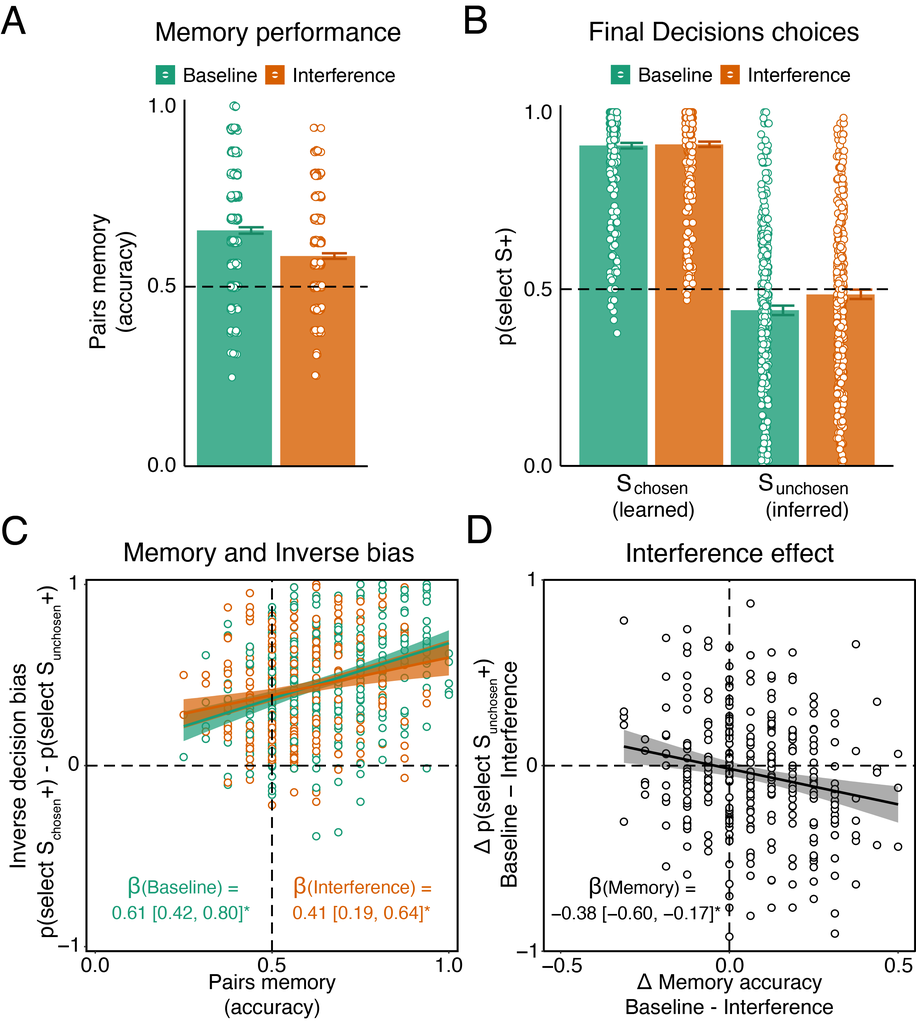

Figure 2. Associative memory modulates the inverse inference of value.

```r
# ==================================
# Panel a: means for memory accuracy
# ==================================

pairs_acc$Condition <- factor(pairs_acc$Condition,levels = c("Baseline", "Interference"))

p1 <- ggplot(subset(pairs_acc, Exp=="Exp1"), aes(x=Condition,y=pairs_acc,group=Condition)) +
  stat_summary_bin(aes(y=pairs_acc, fill=Condition), fun="mean", geom="bar", binwidth=0.2, position=position_dodge(width=1)) +
  geom_point(aes(color=Condition), position=position_jitterdodge(dodge.width=1, jitter.width=0.2, jitter.height=0.005),
                   fill="white", shape=21, stroke=point_stroke-0.3, size=point_size-2) +
  #scale_color_manual(values="black") +
  stat_summary(aes(color=Condition),fun.data=mean_se, fun.args = list(mult=n_sem), geom="errorbar", width=0.3, size=0.9,
               position=position_nudge(0.2)) + # "turquoise4"
  geom_hline(yintercept=0.5, size=line_size, linetype="dashed") +
  scale_y_continuous(expand=c(0,0), breaks=c(0,0.5,1), limits=c(0,1.02)) +
  theme +
  theme(legend.position="top",
        axis.title.x=element_blank(),
        aspect.ratio=2/1,
        plot.title = element_text(margin=margin(0,0,30,0))) +
  labs(y="Pairs memory\n(accuracy)", title="Memory performance") +
  scale_fill_brewer(palette=color_pallete) +
  scale_color_brewer(palette=color_pallete)

# ==========================
# Panel b: means for p(gain)
# ==========================

bias <- subset(dfs$final_decisions, Exp=="Exp1") %>%
  mutate(Choice = ifelse(chosen_trial==1, "Chosen", "Unchosen"),
         Condition = ifelse(condition==1, "Interference", "Baseline")) %>%
  subset(!is.na(rt)) %>%
  group_by(PID, Choice, Condition) %>%
  dplyr::summarize(p_gain = mean(higher_outcome_chosen, na.rm=1)) %>%
  mutate(Condition = factor(Condition,levels = c("Baseline", "Interference")))

p2 <- ggplot(bias, aes(x=Choice,y=p_gain,group=Condition)) +
  stat_summary_bin(aes(y=p_gain, fill=Condition), fun="mean", geom="bar", binwidth=0.2, position=position_dodge(width=1)) +
  geom_point(aes(color=Condition), position=position_jitterdodge(dodge.width=1, jitter.width=0.1),
                   fill="white", shape=21, stroke=point_stroke-0.3, size=point_size-2) +
  #scale_color_manual(values="black") +
  stat_summary(aes(color=Condition),fun.data=mean_se, fun.args = list(mult=n_sem), geom="errorbar", width=0.3, size=0.9, position=position_dodge(1)) + # "turquoise4"
  geom_hline(yintercept=0.5, size=line_size, linetype="dashed") +
  scale_y_continuous(expand=c(0,0), breaks=c(0,0.5,1), limits=c(0,1.02)) +
  theme +
  theme(axis.title.x=element_blank(),
        aspect.ratio=13/12,
        plot.title = element_text(margin=margin(0,0,30,0))) +
  labs(y="p(select S+)", title="Final Decisions Choices") +
  scale_x_discrete(breaks = c("Chosen","Unchosen"), limits=c("Chosen","Unchosen"),
                   labels = c("Chosen" = expression(S[chosen]*" (learned)"),
                              "Unchosen" = expression(S[unchosen]*" (inferred)"))) +
  scale_fill_brewer(palette=color_pallete) +
  scale_color_brewer(palette=color_pallete)

# ================================
# Panel c: memory and inverse bias
# ================================

memory_bias_Exp1 <- subset(memory_bias, Exp=="Exp1") %>%
  mutate(condition = factor(Condition, levels = c("Baseline", "Interference")))

# plot inverse bias and pairs memory

n_fake_samples = 1000
min_x = min(memory_bias_Exp1$pairs_acc)
max_x = max(memory_bias_Exp1$pairs_acc)
model_draws = sum_coefs_memory_bias_Exp1$M_memory_bias_draws_Exp1
conditions = c("Interference","Baseline")
conditions_col_names = c("condition")
is_logistic = 0
predicted_draws_memory_bias <- create_posterior_draws_lines(n_fake_samples, min_x, max_x, model_draws, conditions, conditions_col_names, is_logistic)
predicted_draws_memory_bias <- predicted_draws_memory_bias %>%
  mutate(inverse_bias = median,
         pairs_acc = x) %>%
  mutate(condition = factor(condition, levels = c("Baseline", "Interference")))

# model text
memory_bias_model_text <- subset(sum_coefs_memory_bias_Exp1$summary_coefs_memory_bias_Exp1, grepl("intercept_",Coefficient) | grepl("slope_",Coefficient)) %>%
  separate(Coefficient, c("Coefficient","condition"), "_") %>%
  mutate(text = sprintf("\u03b2(%s) = \n%s", Coefficient, `Median and 95% HDI`)) %>%
  mutate(x = ifelse(Coefficient=="slope" & condition == "Interference", 0.75, 0.25),
         y = ifelse(Coefficient=="slope" & condition == "Baseline", -0.7, -0.7)) %>%
  subset(Coefficient=="slope") %>%
  subset(condition!="diff")

p3 <- ggplot(memory_bias_Exp1, aes(y=inverse_bias,x=pairs_acc, color=condition)) +
  geom_point(size=point_size-1, fill="white", shape=21, stroke=point_stroke) +
  theme +
  point_plot_theme +
  geom_ribbon(data = predicted_draws_memory_bias,
              aes(ymin=lower, ymax=upper, fill=condition), color=NA) +
  geom_line(data=predicted_draws_memory_bias, aes(y=median, color=condition), size=line_size*1.5) +
  geom_hline(yintercept=0, size=line_size, linetype="dashed") +
  geom_vline(xintercept=0.5, size=line_size,  linetype="dashed") +
  scale_y_continuous(expand=c(0,0),  breaks=c(-1,0,1), limits=c(-1.025,1.025)) +
  scale_x_continuous(expand=c(0,0), breaks=c(0, 0.5, 1), limits=c(-0.025, 1.025)) +
  theme(legend.position="none", plot.title = element_text(margin=margin(0,0,30,0))) +
  labs(y=expression(atop("Inverse decision bias","p(select "*S[chosen]*"+) - p(select "*S[unchosen]*"+)")),
       x="Pairs memory\n(accuracy)",
       title="Memory and Inverse bias") +
  geom_text(data=memory_bias_model_text,  mapping=aes(x=x, y=y, label=text, color=condition), size=8) +
  scale_fill_brewer(palette=color_pallete) +
  scale_color_brewer(palette=color_pallete)


# ================================
# Panel c: difference scores
# ================================

difference_scores_unchosen_Exp1 <- subset(difference_scores_unchosen, Exp=="Exp1")

# plot inverse bias and pairs memory

n_fake_samples = 1000
min_x = min(difference_scores_unchosen_Exp1$pairs_acc_score)
max_x = max(difference_scores_unchosen_Exp1$pairs_acc_score)
model_draws = sum_coefs_difference_scores_unchosen_Exp1$M_draws_Exp1 %>%
  mutate(intercept_memory = `(Intercept)`,
         slope_memory = pairs_acc_score)
conditions = c("memory")
conditions_col_names = c()
is_logistic = 0
predicted_draws_difference_scores_unchosen <- create_posterior_draws_lines(n_fake_samples, min_x, max_x, model_draws, conditions, conditions_col_names, is_logistic)
predicted_draws_difference_scores_unchosen <- predicted_draws_difference_scores_unchosen %>%
  mutate(unchosen_pgain_score = median,
         pairs_acc_score = x)

# model text
difference_scores_unchosen_text <- sum_coefs_difference_scores_unchosen_Exp1$summary_coefs_Exp1 %>%
  subset(Coefficient == "pairs_acc_score") %>%
  mutate(text = sprintf("\u03b2(Memory) = \n%s", `Median and 95% HDI`)) %>%
  mutate(x = -0.2,
         y = -0.8) %>%
  subset(Coefficient == "pairs_acc_score")

p4 <- ggplot(difference_scores_unchosen_Exp1, aes(y=unchosen_pgain_score,x=pairs_acc_score)) +
  geom_point(size=point_size-1, fill="white", shape=21, stroke=point_stroke) +
  theme +
  point_plot_theme +
  geom_ribbon(data = predicted_draws_difference_scores_unchosen,
              aes(ymin=lower, ymax=upper), color="light grey") +
  geom_line(data=predicted_draws_difference_scores_unchosen, aes(y=median), size=line_size*1.5) +
  geom_hline(yintercept=0, size=line_size, linetype="dashed") +
  geom_vline(xintercept=0, size=line_size,  linetype="dashed") +
  scale_y_continuous(expand=c(0,0),  breaks=c(-1,0,1), limits=c(-1,1)) +
  scale_x_continuous(expand=c(0,0), breaks=c(-0.5, 0, 0.5), limits=c(-0.55,0.55)) +
  theme(legend.position="none", plot.title = element_text(margin=margin(0,0,30,0))) +
  labs(y=expression(atop("p(select "*S[unchosen]*"+)","Baseline - Interference")),
       x="Memory accuracy\nBaseline - Interference",
       title="The effect of interference") +
  geom_text(data=difference_scores_unchosen_text,  mapping=aes(x=x, y=y, label=text), size=8) +
  scale_fill_brewer(palette=color_pallete) +
  scale_color_brewer(palette=color_pallete)


# p <- plot_grid(p1,p2,p3,p4,
#                ncol=2,nrow=2,
#                #axis="bt",
#                #align="v",
#                labels=c("a","b","c","d"),
#                label_size = 30,
#                label_fontfamily = "Helvetica",
#                rel_heights = c(1,1,1,1),
#                rel_widths = c(0.5,1,1,1))


pa <- plot_grid(p1,p2,
               ncol=2,nrow=1,
               axis="bt",
               align="v",
               labels=c("a","b"),
               label_size = 30,
               label_fontfamily = "Helvetica",
               rel_heights = c(0.7,1),
               rel_widths = c(0.5,0.8))

pb <- plot_grid(p3,p4,
               ncol=2,nrow=1,
               axis="bt",
               align="v",
               labels=c("c","d"),
               label_size = 30,
               label_fontfamily = "Helvetica",
               rel_heights = c(1,1),
               rel_widths = c(1,1))

if (Save_plots == 1) {ggsave(filename=sprintf("Plots/%s.%s","Figure2a","eps"),
                             plot=pa,
                             width=fig_size[1],
                             height=fig_size[2]-4)}

if (Save_plots == 1) {ggsave(filename=sprintf("Plots/%s.%s","Figure2b","eps"),
                             plot=pb,
                             width=fig_size[1]+5,
                             height=fig_size[2]+1)}
```

## Model fitting

### Arrange data for fitting

```r
# ==============================================================================
# create deliberation matrix
# ==============================================================================

deliberation_csv <- dfs$deliberation %>%
  mutate(reward_type = ifelse(reward_type==1,1,0),
         rating_chosen = ifelse(left_chosen==1, rating_left, rating_right),
         rating_unchosen = ifelse(left_chosen==0, rating_left, rating_right),
         zscored_rating_chosen = ifelse(left_chosen==1, zcored_rating_left, zcored_rating_right),
         zscored_rating_unchosen = ifelse(left_chosen==0, zcored_rating_left, zcored_rating_right)) %>%
  subset(block==3) %>%
  dplyr::select(Exp, PID, condition, reward_type, chosen_obj, unchosen_obj, rating_chosen, rating_unchosen, zscored_rating_chosen, zscored_rating_unchosen)

# add reward amount
reward_learning <- dfs$reward_learning %>%
  dplyr::select(PID, stimulus_id, reward_amount) %>%
  rename(chosen_obj = stimulus_id,
         reward = reward_amount) %>%
  distinct()

deliberation_csv <- deliberation_csv %>%
  merge(reward_learning, by=c("PID", "chosen_obj")) %>%
  mutate(memory_score_chosen = NaN,
         memory_score_unchosen = NaN)

# add memory score
memory_left <- dfs$memory %>%
  dplyr::select(PID, stimulus_left, pairs_acc) %>%
  dplyr::rename(obj = stimulus_left)
memory_right <- dfs$memory %>%
  dplyr::select(PID, stimulus_right, pairs_acc) %>%
  dplyr::rename(obj = stimulus_right)

memory_score <- bind_rows(memory_left, memory_right) %>%
  group_by(PID, obj) %>%
  dplyr::summarise(memory_score = sum(pairs_acc)/2)

# add memory score to deliberation matrix
for (i in 1:nrow(deliberation_csv)){
  deliberation_csv$memory_score_chosen[i] = memory_score$memory_score[memory_score$PID == deliberation_csv$PID[i] & memory_score$obj == deliberation_csv$chosen_obj[i]]
  deliberation_csv$memory_score_unchosen[i] = memory_score$memory_score[memory_score$PID == deliberation_csv$PID[i] & memory_score$obj == deliberation_csv$unchosen_obj[i]]
}

deliberation_csv <- deliberation_csv %>%
  arrange(Exp, PID)

# ==============================================================================
# create final decisions matrix
# ==============================================================================

final_decisions_csv = dfs$final_decisions %>%
  dplyr::select(Exp, PID, block, trial, condition, chosen_trial, left_chosen, gain_left, stimulus_left, stimulus_right, rating_left, rating_right, zcored_rating_left, zcored_rating_right, chosen_obj, unchosen_obj, higher_outcome_chosen) %>%
  dplyr::rename(zrating_left = zcored_rating_left,
                zrating_right = zcored_rating_right,
                gain_item_chosen = higher_outcome_chosen) %>%
  mutate(choice_type = ifelse(chosen_trial==1, "chosen_pair", "unchosen_pair"),
         condition = ifelse(condition==1, "interference", "baseline"),
         no_response_trial = ifelse(is.na(left_chosen), 1, 0))

final_decisions_csv <- final_decisions_csv %>%
  arrange(Exp, PID)

# save
write.csv(deliberation_csv, file = "../Policy_gradient_model/data/deliberation_choices.csv")
write.csv(final_decisions_csv, file = "../Policy_gradient_model/data/final_decisions_choices.csv")
```

### Difference between models

```r
# load data (created in a separate matlab code after fitting)

model_preds <- read.csv("../Policy_gradient_model/data/fd_predictions.csv")

# ==========================================================
# Analyse difference between conditions in predicted p(gain)
# ==========================================================

p_gain_models_conds <- model_preds %>%
  rename(variable = gain_prob_variable, fixed = gain_prob_fixed, perfect = gain_prob_perfect) %>%
  tidyr::gather(model, predicted_p_gain, variable:perfect) %>%
  mutate(p_gain_choice = ifelse(gain_item_chosen==1, predicted_p_gain, 1-predicted_p_gain)) %>%
  group_by(PID, model, choice_type, condition) %>%
  dplyr::summarise(predicted_pgain = mean(p_gain_choice, na.rm=1))

print("Variable-memory model")
```

```
## [1] "Variable-memory model"
```

```r
t.test(predicted_pgain ~ condition, data = subset(p_gain_models_conds, model=="variable" & choice_type == "unchosen_pair"), paired=TRUE)
```

```
##
##  Paired t-test
##
## data:  predicted_pgain by condition
## t = -4.2126, df = 314, p-value = 3.302e-05
## alternative hypothesis: true mean difference is not equal to 0
## 95 percent confidence interval:
##  -0.011248064 -0.004086077
## sample estimates:
## mean difference
##    -0.007667071
```

```r
print("Fixed-memory model")
```

```
## [1] "Fixed-memory model"
```

```r
t.test(predicted_pgain ~ condition, data = subset(p_gain_models_conds, model=="fixed" & choice_type == "unchosen_pair"), paired=TRUE)
```

```
##
##  Paired t-test
##
## data:  predicted_pgain by condition
## t = -2.092, df = 314, p-value = 0.03724
## alternative hypothesis: true mean difference is not equal to 0
## 95 percent confidence interval:
##  -9.157812e-04 -2.808316e-05
## sample estimates:
## mean difference
##   -0.0004719322
```

```r
print("Perfect-memory model")
```

```
## [1] "Perfect-memory model"
```

```r
t.test(predicted_pgain ~ condition, data = subset(p_gain_models_conds, model=="perfect" & choice_type == "unchosen_pair"), paired=TRUE)
```

```
##
##  Paired t-test
##
## data:  predicted_pgain by condition
## t = -1.8527, df = 314, p-value = 0.06486
## alternative hypothesis: true mean difference is not equal to 0
## 95 percent confidence interval:
##  -6.746796e-04  2.028003e-05
## sample estimates:
## mean difference
##   -0.0003271998
```

### Figure 3

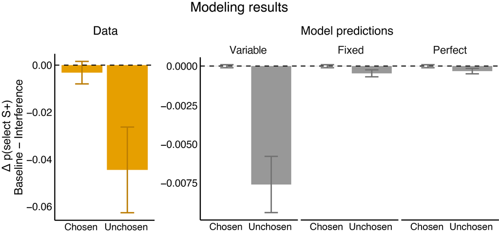

Figure 3. The variable-memory model best predicts the key empirical finding in Experiment 1.

```r
# ==================================================================
# Plot difference in predicted p(gain) for chosen and unchosen pairs
# ==================================================================

p_gain_choice <- model_preds %>%
  group_by(PID, choice_type, condition) %>%
  dplyr::summarise(pgain = mean(gain_item_chosen, na.rm=1)) %>%
  tidyr::spread(condition, pgain) %>%
  mutate(pgain_diff = baseline - interference,
         model = "data") %>%
  dplyr::select(-c(interference, baseline))

p_gain_models <- model_preds %>%
  rename(variable = gain_prob_variable, fixed = gain_prob_fixed, perfect = gain_prob_perfect) %>%
  tidyr::gather(model, predicted_p_gain, variable:perfect) %>%
  mutate(p_gain_choice = ifelse(gain_item_chosen==1, predicted_p_gain, 1-predicted_p_gain)) %>%
  group_by(PID, model, choice_type, condition) %>%
  dplyr::summarise(predicted_pgain = mean(p_gain_choice, na.rm=1)) %>%
  tidyr::spread(condition, predicted_pgain) %>%
  mutate(pgain_diff = baseline - interference) %>%
  dplyr::select(-c(interference, baseline)) %>%
  bind_rows(p_gain_choice) %>%
  mutate(model = factor(model, levels=c("data", "variable", "fixed", "perfect"))) %>%
  mutate(choice_type = ifelse(choice_type=="chosen_pair", "Chosen", "Unchosen"))

# plot the data separately from the model
p1 <- ggplot(subset(p_gain_models, model!="data"), aes(x=choice_type,y=pgain_diff)) +
  stat_summary_bin(aes(y=pgain_diff, fill=model), fun="mean", geom="bar", binwidth=0.2, position=position_dodge(width=1)) +
  # geom_point(aes(color=model), position=position_jitterdodge(dodge.width=1, jitter.width=0.1),
  #                  fill="white", shape=21, stroke=point_stroke-0.3, size=0.5, alpha=0.5) +
  stat_summary(aes(color=model),fun.data=mean_se, fun.args = list(mult=n_sem), geom="errorbar", width=0.3, size=0.9, position=position_dodge(1)) + # "turquoise4"
  labs(title = "Model predictions") +
  geom_hline(yintercept=0, size=line_size, linetype="dashed") +
  theme +
  theme(strip.text.x = element_text(size = 21),
        axis.title = element_text(size = 21),
        axis.text = element_text(size = 19, color = "black"),
        axis.title.x=element_blank(),
        axis.title.y=element_blank(),
        aspect.ratio=5/3,
        plot.title = element_text(margin=margin(0,0,30,0)),
        legend.position="none") +
  scale_fill_manual(values=c("#999999","#999999","#999999")) +
  scale_color_manual(values=c("#999999","#999999","#999999")) +
  facet_wrap(.~model)

p2 <- ggplot(subset(p_gain_models, model=="data"), aes(x=choice_type,y=pgain_diff)) +
  stat_summary_bin(aes(y=pgain_diff, fill=model), fun="mean", geom="bar", binwidth=0.2, position=position_dodge(width=1)) +
  # geom_point(aes(color=model), position=position_jitterdodge(dodge.width=1, jitter.width=0.1),
  #                  fill="white", shape=21, stroke=point_stroke-0.3, size=0.5, alpha=0.5) +
  stat_summary(aes(color=model),fun.data=mean_se, fun.args = list(mult=n_sem), geom="errorbar", width=0.3, size=0.9, position=position_dodge(1)) + # "turquoise4"
  labs(y="\u0394 p(select S+)\nBaseline - Interference",
       title = "Data") +
  #scale_y_continuous(expand=c(0,0)) +
  geom_hline(yintercept=0, size=line_size, linetype="dashed") +
  theme +
  theme(strip.text.x = element_text(size = 21),
        axis.title = element_text(size = 21),
        axis.text = element_text(size = 19, color = "black"),
        axis.title.x=element_blank(),
        aspect.ratio=5/3,
        plot.title = element_text(margin=margin(0,0,30,0)),
        legend.position="none") +
  scale_fill_manual(values=c("#E69F00")) +
  scale_color_manual(values=c("#E69F00"))


p <- plot_grid(p2,p1,
               ncol=2,nrow=1,
               axis="bt",
               align="v",
               labels=c("a","b"),
               label_size = 30,
               label_fontfamily = "Helvetica",
               rel_heights = c(1,1),
               rel_widths = c(0.46,1))


if (Save_plots == 1) {ggsave(filename=sprintf("Plots/%s.%s","Figure3","eps"),
                             plot=p,
                             width=fig_size[1]+3,
                             height=fig_size[2]-4)}
```

## Supplementary Material analyses

### Supplementary Figures

#### Supplementary Figure 1

```r
outcome_estimation_fig <- subset(dfs$outcome_evaluation, Exp=="Exp1") %>%
  mutate(Choice = ifelse(stim_type=="chosen", "Chosen", ifelse(stim_type=="unchosen","Unchosen","Novel")),
         Outcome = ifelse(outcome==1, "S+", "S0"),
         Condition = ifelse(condition==1, "Interference", "Baseline")) %>%
  group_by(PID, Condition, Choice, Outcome) %>%
  dplyr::summarise(gain_eval = mean(outcome_eval_gain, na.rm=1))

p <- ggplot(outcome_estimation_fig %>%
               mutate(Condition = factor(Condition, levels = c("Baseline", "Interference")),
                      Choice = factor(Choice, levels = c("Chosen", "Unchosen", "Novel"))),
             aes(x=Outcome,y=gain_eval,group=Condition)) +
  stat_summary_bin(aes(y=gain_eval, fill=Condition), fun="mean", geom="bar", binwidth=0.2, position=position_dodge(width=1), alpha=0.7) +
  # geom_point(aes(color=Condition), position=position_jitterdodge(dodge.width=1, jitter.width=0.1),
  #                  fill="white", shape=21, stroke=point_stroke, size=point_size-2) +
  #scale_color_manual(values="black") +
  stat_summary(aes(color=Condition),fun.data=mean_se, fun.args = list(mult=n_sem), geom="errorbar", width=0.3, size=0.9, position=position_dodge(1)) + # "turquoise4"
  geom_hline(yintercept=0.5, size=line_size, linetype="dashed") +
  scale_y_continuous(expand=c(0,0), breaks=c(0,0.5,1), limits=c(0,1)) +
  theme +
  theme(axis.title.x=element_blank(),
        aspect.ratio=3/2,
        plot.title = element_text(margin=margin(0,0,30,0)),
        strip.text = element_text(size=25),
        legend.text=element_text(size=20)) +
  labs(y="p(estimate item as S+)", title="Outcome Estimation") +
  #scale_x_discrete(breaks = c("Chosen","Unchosen","Novel"), limits=c("Chosen","Unchosen","Novel")) +
  scale_fill_brewer(palette=color_pallete) +
  scale_color_brewer(palette=color_pallete) +
  facet_wrap(.~Choice)

if (Save_plots == 1) {ggsave(filename=sprintf("Plots/%s.%s","Supp_Figure1",fig_type),
                             plot=p,
                             width=fig_size[1]+3,
                             height=fig_size[2]-2)}
```

[figure not shown]

Supplementary Figure 1. Outcome Estimation reports mirror the inverse decision bias in the Final Decisions phase (n = 315).

### Supplementary Text

#### Supplementart Text 1 - Potential alternative explanations

```r
# ==============================================================================
# Temporal Lag
# ==============================================================================

subs <- unique(dfs$final_decisions$PID)

deliberation_lags <- dfs$deliberation %>%
  subset(block==1) %>%
  mutate(temporal_lag = ifelse(trial %in% c(0:7),"first_lag", "second_lag")) %>%
  dplyr::select(Exp, PID, temporal_lag, chosen_obj, unchosen_obj)

memory_lags <- dfs$memory %>%
  subset(old_pair == 1) %>%
  mutate(temporal_lag = NaN)
for (t in 1:nrow(memory_lags)){
  memory_lags$temporal_lag[t] <- deliberation_lags[(deliberation_lags$PID == memory_lags$PID[t]) & (deliberation_lags$chosen_obj %in% memory_lags$chosen_obj[t] | deliberation_lags$unchosen_obj %in% memory_lags$chosen_obj[t]),"temporal_lag"]

}

pairs_acc_lag <- memory_lags %>%
  group_by(Exp, PID, temporal_lag) %>%
  dplyr::summarize(pairs_acc = mean(pairs_acc, na.rm=1))

# ttest
print("testing the difference in memory between temporal lag conditions - Exp1")
```

```
## [1] "testing the difference in memory between temporal lag conditions - Exp1"
```

```r
t.test(as.numeric(unlist(pairs_acc_lag[pairs_acc_lag$Exp=="Exp1" & pairs_acc_lag$temporal_lag=="first_lag", "pairs_acc"])),
       as.numeric(unlist(pairs_acc_lag[pairs_acc_lag$Exp=="Exp1" & pairs_acc_lag$temporal_lag=="second_lag", "pairs_acc"])),
       paired=TRUE)
```

```
##
##  Paired t-test
##
## data:  as.numeric(unlist(pairs_acc_lag[pairs_acc_lag$Exp == "Exp1" &  and as.numeric(unlist(pairs_acc_lag[pairs_acc_lag$Exp == "Exp1" &     pairs_acc_lag$temporal_lag == "first_lag", "pairs_acc"])) and     pairs_acc_lag$temporal_lag == "second_lag", "pairs_acc"]))
## t = -0.19137, df = 314, p-value = 0.8484
## alternative hypothesis: true mean difference is not equal to 0
## 95 percent confidence interval:
##  -0.02686047  0.02209857
## sample estimates:
## mean difference
##    -0.002380952
```

```r
print("testing the difference in memory between temporal lag conditions - Pilot")
```

```
## [1] "testing the difference in memory between temporal lag conditions - Pilot"
```

```r
t.test(as.numeric(unlist(pairs_acc_lag[pairs_acc_lag$Exp=="Pilot" & pairs_acc_lag$temporal_lag=="first_lag", "pairs_acc"])),
       as.numeric(unlist(pairs_acc_lag[pairs_acc_lag$Exp=="Pilot" & pairs_acc_lag$temporal_lag=="second_lag", "pairs_acc"])),
       paired=TRUE)
```

```
##
##  Paired t-test
##
## data:  as.numeric(unlist(pairs_acc_lag[pairs_acc_lag$Exp == "Pilot" &  and as.numeric(unlist(pairs_acc_lag[pairs_acc_lag$Exp == "Pilot" &     pairs_acc_lag$temporal_lag == "first_lag", "pairs_acc"])) and     pairs_acc_lag$temporal_lag == "second_lag", "pairs_acc"]))
## t = 0.86417, df = 107, p-value = 0.3894
## alternative hypothesis: true mean difference is not equal to 0
## 95 percent confidence interval:
##  -0.02396267  0.06099971
## sample estimates:
## mean difference
##      0.01851852
```

```r
# ==============================================================================
# Reward Value
# ==============================================================================

# check whether memory is modulated by reward amount

# add reward value to the memory analysis
reward_value <- dfs$reward_learning %>%
  subset(block == 1) %>%
  group_by(Exp, PID, stimulus_id) %>%
  dplyr::summarise(reward_amount = mean(reward_amount, na.rm=1)) %>%
  rename(chosen_object = stimulus_id)

memory_reward <- dfs$memory %>%
  mutate(Condition = ifelse(condition==1, "Interference", "Baseline")) %>%
  subset(old_pair == 1) %>%
  merge(reward_value, by=c("Exp","PID", "chosen_object")) %>%
  mutate(gain = ifelse(reward_amount == 0, -1, 1),
         condition_centered = ifelse(condition==1, 1, -1))

# check whether pairs memory is better for gains vs no-gain items
memory_reward_group <- memory_reward %>%
  group_by(Exp, PID, condition, gain) %>%
  dplyr::summarise(pairs_acc = mean(pairs_acc)) %>%
  group_by(Exp, condition, gain) %>%
  dplyr::summarise(mean_pairs_acc = mean(pairs_acc), se_pairs_acc=sd(pairs_acc)/sqrt(n())) %>%
  mutate(`Mean and SE` = sprintf("%.2f \u00b1 %.2f", mean_pairs_acc, se_pairs_acc),
         Condition = ifelse(condition==1, "Interference", "Baseline"),
         `Reward type` = ifelse(gain==1, "S+", "S0")) %>%
  rename(Experiment = Exp) %>%
  dplyr::select(Experiment, Condition, `Reward type`, `Mean and SE`)


memory_reward_group %>%
  kbl(caption = "Memory performance as a function of reward type and condition") %>%
  kable_paper("hover", full_width = F, html_font = "Helvetica", position = "left")
```

Memory performance as a function of reward type and condition

| condition | Experiment | Condition | Reward type | Mean and SE |
| --- | --- | --- | --- | --- |
| 0 | Exp1 | Baseline | S0 | 0.71 ± 0.02 |
| 0 | Exp1 | Baseline | S+ | 0.74 ± 0.02 |
| 1 | Exp1 | Interference | S0 | 0.57 ± 0.02 |
| 1 | Exp1 | Interference | S+ | 0.61 ± 0.02 |
| 0 | Pilot | Baseline | S0 | 0.69 ± 0.03 |
| 0 | Pilot | Baseline | S+ | 0.77 ± 0.02 |
| 1 | Pilot | Interference | S0 | 0.57 ± 0.03 |
| 1 | Pilot | Interference | S+ | 0.62 ± 0.03 |

```r
print("mixed effects model predicting memory accuracy as a function of reward type and condition")
```

```
## [1] "mixed effects model predicting memory accuracy as a function of reward type and condition"
```

```r
# test this formaly
M_memory_gain_Exp1 <- glmer(data = memory_reward %>% subset(Exp=="Exp1"),
                                   pairs_acc ~ condition*gain + (condition*gain | PID),
                                   family = binomial(link="logit"))

summary(M_memory_gain_Exp1)
```

```
## Generalized linear mixed model fit by maximum likelihood (Laplace
##   Approximation) [glmerMod]
##  Family: binomial  ( logit )
## Formula: pairs_acc ~ condition * gain + (condition * gain | PID)
##    Data: memory_reward %>% subset(Exp == "Exp1")
##
##      AIC      BIC   logLik deviance df.resid
##   6113.9   6205.2  -3042.9   6085.9     5026
##
## Scaled residuals:
##     Min      1Q  Median      3Q     Max
## -2.5905 -0.9064  0.4551  0.6676  1.7308
##
## Random effects:
##  Groups Name           Variance Std.Dev. Corr
##  PID    (Intercept)    1.03388  1.0168
##         condition      0.58487  0.7648   -0.60
##         gain           0.06740  0.2596    0.53 -0.61
##         condition:gain 0.08495  0.2915   -0.57  0.88 -0.91
## Number of obs: 5040, groups:  PID, 315
##
## Fixed effects:
##                Estimate Std. Error z value Pr(>|z|)
## (Intercept)     1.18961    0.08051  14.775   <2e-16 ***
## condition      -0.77149    0.08373  -9.214   <2e-16 ***
## gain            0.14940    0.05821   2.567   0.0103 *
## condition:gain -0.03576    0.07356  -0.486   0.6269
## ---
## Signif. codes:  0 '***' 0.001 '**' 0.01 '*' 0.05 '.' 0.1 ' ' 1
##
## Correlation of Fixed Effects:
##             (Intr) condtn gain
## condition   -0.693
## gain         0.199 -0.179
## conditin:gn -0.173  0.199 -0.793
## optimizer (Nelder_Mead) convergence code: 0 (OK)
## Model failed to converge with max|grad| = 0.0141655 (tol = 0.002, component 1)
```

```r
# now look at gains only - do we find that gain value predicts pairs memory?

print("mixed effects model predicting memory accuracy as a function of reward amount")
```

```
## [1] "mixed effects model predicting memory accuracy as a function of reward amount"
```

```r
M_memory_reward_amount_Exp1 <- glmer(data = memory_reward %>% subset(Exp=="Exp1" & gain==1),
                                   pairs_acc ~ reward_amount + (reward_amount | PID),
                                   family = binomial(link="logit"))

summary(M_memory_reward_amount_Exp1)
```

```
## Generalized linear mixed model fit by maximum likelihood (Laplace
##   Approximation) [glmerMod]
##  Family: binomial  ( logit )
## Formula: pairs_acc ~ reward_amount + (reward_amount | PID)
##    Data: memory_reward %>% subset(Exp == "Exp1" & gain == 1)
##
##      AIC      BIC   logLik deviance df.resid
##   3101.2   3130.3  -1545.6   3091.2     2515
##
## Scaled residuals:
##     Min      1Q  Median      3Q     Max
## -1.9418 -1.0312  0.5175  0.6287  1.3275
##
## Random effects:
##  Groups Name          Variance  Std.Dev. Corr
##  PID    (Intercept)   4.332e-01 0.658180
##         reward_amount 9.349e-05 0.009669 -1.00
## Number of obs: 2520, groups:  PID, 315
##
## Fixed effects:
##                Estimate Std. Error z value Pr(>|z|)
## (Intercept)   0.7245307  1.3310693   0.544    0.586
## reward_amount 0.0007804  0.0088803   0.088    0.930
##
## Correlation of Fixed Effects:
##             (Intr)
## reward_amnt -0.999
## optimizer (Nelder_Mead) convergence code: 0 (OK)
## boundary (singular) fit: see help('isSingular')
```

```r
# check whether inverse bias is modulated by reward amount

reward_deliberation <- dfs$deliberation %>%
  subset(block==3) %>%
  rename(chosen_object = chosen_obj, unchosen_object = unchosen_obj) %>%
  merge(reward_value, by=c("Exp", "PID", "chosen_object"))

reward_fd <- dfs$final_decisions %>%
  mutate(reward_amount_left = NaN,
         reward_amount_right = NaN,
         reward_amount_gain = NaN)

for (i in 1:nrow(reward_fd)){
  if (reward_fd[i, "chosen_trial"] == 1){
    reward_fd[i, "reward_amount_left"] <- reward_deliberation[reward_deliberation$PID == reward_fd[i, "PID"] & reward_deliberation$chosen_object == reward_fd[i, "stimulus_left"], "reward_amount"]
    reward_fd[i, "reward_amount_right"] <- reward_deliberation[reward_deliberation$PID == reward_fd[i, "PID"] & reward_deliberation$chosen_object == reward_fd[i, "stimulus_right"], "reward_amount"]
  } else {
    reward_fd[i, "reward_amount_left"] <- reward_deliberation[reward_deliberation$PID == reward_fd[i, "PID"] & reward_deliberation$unchosen_object == reward_fd[i, "stimulus_left"], "reward_amount"]
    reward_fd[i, "reward_amount_right"] <- reward_deliberation[reward_deliberation$PID == reward_fd[i, "PID"] & reward_deliberation$unchosen_object == reward_fd[i, "stimulus_right"], "reward_amount"]
  }
}
reward_fd <- reward_fd %>%
  mutate(reward_amount_gain = ifelse(gain_left==1, reward_amount_left, reward_amount_right),
         condition_center = ifelse(condition==0, -1, 1),
         choice_center = ifelse(chosen_trial==0, -1, 1)) %>%
  subset(!is.nan(rt))

# zscore reward amount
library("mosaic")
reward_fd <- reward_fd %>%
  mutate(reward_amount_gain_zscore = zscore(reward_amount_gain))

M_choice_reward_Exp1 <- glmer(data = subset(reward_fd, Exp=="Exp1" & chosen_trial==0),
                                   higher_outcome_chosen ~
                                     condition_center*reward_amount_gain_zscore +
                                     (condition_center*reward_amount_gain_zscore | PID),
                                   family = binomial(link="logit"))

print("mixed effects model predicting p(gain) as a function of reward amount of the gain item - Exp1")
```

```
## [1] "mixed effects model predicting p(gain) as a function of reward amount of the gain item - Exp1"
```

```r
summary(M_choice_reward_Exp1)
```

```
## Generalized linear mixed model fit by maximum likelihood (Laplace
##   Approximation) [glmerMod]
##  Family: binomial  ( logit )
## Formula:
## higher_outcome_chosen ~ condition_center * reward_amount_gain_zscore +
##     (condition_center * reward_amount_gain_zscore | PID)
##    Data: subset(reward_fd, Exp == "Exp1" & chosen_trial == 0)
##
##      AIC      BIC   logLik deviance df.resid
##  46687.5  46807.9 -23329.8  46659.5    39937
##
## Scaled residuals:
##     Min      1Q  Median      3Q     Max
## -4.9399 -0.7533 -0.2489  0.7886  5.1960
##
## Random effects:
##  Groups Name                                       Variance Std.Dev. Corr
##  PID    (Intercept)                                0.9421   0.9706
##         condition_center                           0.8136   0.9020   -0.09
##         reward_amount_gain_zscore                  0.1886   0.4343   -0.04
##         condition_center:reward_amount_gain_zscore 0.1859   0.4312    0.10
##
##
##
##  -0.06
##  -0.18 -0.27
## Number of obs: 39951, groups:  PID, 315
##
## Fixed effects:
##                                            Estimate Std. Error z value Pr(>|z|)
## (Intercept)                                -0.20957    0.05663  -3.700 0.000215
## condition_center                            0.10837    0.05290   2.049 0.040510
## reward_amount_gain_zscore                  -0.02692    0.02949  -0.913 0.361291
## condition_center:reward_amount_gain_zscore  0.02048    0.02934   0.698 0.485148
##
## (Intercept)                                ***
## condition_center                           *
## reward_amount_gain_zscore
## condition_center:reward_amount_gain_zscore
## ---
## Signif. codes:  0 '***' 0.001 '**' 0.01 '*' 0.05 '.' 0.1 ' ' 1
##
## Correlation of Fixed Effects:
##             (Intr) cndtn_ rwr___
## condtn_cntr -0.094
## rwrd_mnt_g_ -0.040 -0.049
## cndtn_c:___  0.079 -0.147 -0.212
```

```r
M_choice_reward_Pilot <- glmer(data = subset(reward_fd, Exp=="Pilot" & chosen_trial==0),
                                   higher_outcome_chosen ~
                                     condition_center*reward_amount_gain +
                                     (condition_center*reward_amount_gain | PID),
                                   family = binomial(link="logit"))

print("mixed effects model predicting p(gain) as a function of reward amount of the gain item - Pilot")
```

```
## [1] "mixed effects model predicting p(gain) as a function of reward amount of the gain item - Pilot"
```

```r
summary(M_choice_reward_Pilot)
```

```
## Generalized linear mixed model fit by maximum likelihood (Laplace
##   Approximation) [glmerMod]
##  Family: binomial  ( logit )
## Formula: higher_outcome_chosen ~ condition_center * reward_amount_gain +
##     (condition_center * reward_amount_gain | PID)
##    Data: subset(reward_fd, Exp == "Pilot" & chosen_trial == 0)
##
##      AIC      BIC   logLik deviance df.resid
##  16377.3  16482.7  -8174.7  16349.3    13693
##
## Scaled residuals:
##     Min      1Q  Median      3Q     Max
## -4.8879 -0.7941 -0.2435  0.7978  4.8528
##
## Random effects:
##  Groups Name                                Variance  Std.Dev. Corr
##  PID    (Intercept)                         5.092e+01  7.13564
##         condition_center                    1.784e+02 13.35509 -0.44
##         reward_amount_gain                  2.161e-03  0.04648 -0.99  0.43
##         condition_center:reward_amount_gain 7.645e-03  0.08744  0.45 -1.00
##
##
##
##
##  -0.45
## Number of obs: 13707, groups:  PID, 108
##
## Fixed effects:
##                                      Estimate Std. Error z value Pr(>|z|)
## (Intercept)                         -1.177615   0.984919  -1.196  0.23183
## condition_center                     3.909276   1.453400   2.690  0.00715 **
## reward_amount_gain                   0.006719   0.006491   1.035  0.30058
## condition_center:reward_amount_gain -0.024321   0.009555  -2.545  0.01091 *
## ---
## Signif. codes:  0 '***' 0.001 '**' 0.01 '*' 0.05 '.' 0.1 ' ' 1
##
## Correlation of Fixed Effects:
##             (Intr) cndtn_ rwrd__
## condtn_cntr -0.268
## rwrd_mnt_gn -0.997  0.262
## cndtn_cn:__  0.275 -0.998 -0.269
## optimizer (Nelder_Mead) convergence code: 4 (failure to converge in 10000 evaluations)
## Model failed to converge with max|grad| = 7.09669 (tol = 0.002, component 1)
## Model is nearly unidentifiable: very large eigenvalue
##  - Rescale variables?
## Model is nearly unidentifiable: large eigenvalue ratio
##  - Rescale variables?
## failure to converge in 10000 evaluations
```

```r
# ==============================================================================
# Consistency within and across auctions
# ==============================================================================

# ------------------------------------------------------------------------------
# consistency of choices in the first auction
# ------------------------------------------------------------------------------

p_gain_unchosen <- dfs$final_decisions %>%
  subset(chosen_trial==0 & !is.na(rt)) %>%
  group_by(Exp, PID, condition) %>%
  dplyr::summarise(pgain_unchosen = mean(higher_outcome_chosen))

mem <- dfs$memory %>%
  group_by(Exp, PID, condition) %>%
  dplyr::summarise(pairs_acc = mean(pairs_acc))

consistency_first_auction <- dfs$deliberation %>%
  group_by(Exp, PID, stimulus_left, condition) %>%
  dplyr::summarise(distinct = n_distinct(chosen_obj)) %>%
  mutate(consistency = abs(distinct - 4)) %>%
  dplyr::select(-distinct)

first_auc <- dfs$deliberation %>%
  merge(consistency_first_auction, by=c("Exp","PID","condition","stimulus_left"))

consistency_second_auction <- dfs$Interference %>%
  group_by(Exp, PID, condition, stimulus_left) %>%
  dplyr::summarise(distinct = n_distinct(chosen_obj)) %>%
  mutate(consistency = abs(distinct - 4)) %>%
  dplyr::select(-distinct)

second_auc <- dfs$Interference %>%
  merge(consistency_second_auction, by=c("Exp","PID","condition","stimulus_left"))

consistency_subs_1 <- consistency_first_auction %>%
  group_by(Exp, PID, condition) %>%
  dplyr::summarise(consistency = mean(consistency, na.rm=1)) %>%
  mutate(auction = "first")

consistency_subs <- consistency_second_auction %>%
  group_by(Exp, PID, condition) %>%
  dplyr::summarise(consistency = mean(consistency, na.rm=1)) %>%
  mutate(auction = "second") %>%
  rbind(consistency_subs_1) %>%
  merge(p_gain_unchosen, by=c("Exp", "PID", "condition")) %>%
  merge(mem, by=c("Exp", "PID", "condition")) %>%
  mutate(auction_logical = ifelse(auction == "first", 1, 0))

print("consistency of choices in first and second auctions")
```

```
## [1] "consistency of choices in first and second auctions"
```

```r
consistency_subs %>%
  group_by(Exp, auction) %>%
  dplyr::summarise(mean = mean(consistency), se = sd(consistency)/sqrt(n()))
```

```
## # A tibble: 4 × 4
## # Groups:   Exp [2]
##   Exp   auction  mean      se
##   <chr> <chr>   <dbl>   <dbl>
## 1 Exp1  first    2.89 0.00573
## 2 Exp1  second   2.94 0.00480
## 3 Pilot first    2.89 0.0110
## 4 Pilot second   2.93 0.0100
```

```r
# test whether consistency in the first auction predicted better pairs memory

print("linear regression predicting pairs memory as a function of consistency and condition - Exp1 ")
```

```
## [1] "linear regression predicting pairs memory as a function of consistency and condition - Exp1 "
```

```r
consistency_memory_auc1_Exp1 <- lm(data = consistency_subs %>% subset(auction == "first" & Exp == "Exp1"),
                              pairs_acc ~ consistency*condition)
summary(consistency_memory_auc1_Exp1)
```

```
##
## Call:
## lm(formula = pairs_acc ~ consistency * condition, data = consistency_subs %>%
##     subset(auction == "first" & Exp == "Exp1"))
##
## Residuals:
##      Min       1Q   Median       3Q      Max
## -0.42648 -0.09397 -0.02373  0.09834  0.35420
##
## Coefficients:
##                       Estimate Std. Error t value Pr(>|t|)
## (Intercept)            0.19620    0.16558   1.185  0.23649
## consistency            0.16009    0.05756   2.781  0.00558 **
## condition              0.25229    0.23771   1.061  0.28893
## consistency:condition -0.11320    0.08210  -1.379  0.16846
## ---
## Signif. codes:  0 '***' 0.001 '**' 0.01 '*' 0.05 '.' 0.1 ' ' 1
##
## Residual standard error: 0.1469 on 626 degrees of freedom
## Multiple R-squared:  0.06762,    Adjusted R-squared:  0.06315
## F-statistic: 15.13 on 3 and 626 DF,  p-value: 1.612e-09
```

```r
print("linear regression predicting pairs memory as a function of consistency and condition - Pilot ")
```

```
## [1] "linear regression predicting pairs memory as a function of consistency and condition - Pilot "
```

```r
consistency_memory_auc1_Pilot <- lm(data = consistency_subs %>% subset(auction == "first" & Exp == "Pilot"),
                              pairs_acc ~ consistency*condition)
summary(consistency_memory_auc1_Pilot)
```

```
##
## Call:
## lm(formula = pairs_acc ~ consistency * condition, data = consistency_subs %>%
##     subset(auction == "first" & Exp == "Pilot"))
##
## Residuals:
##      Min       1Q   Median       3Q      Max
## -0.41913 -0.08749 -0.01889  0.10191  0.35611
##
## Coefficients:
##                       Estimate Std. Error t value Pr(>|t|)
## (Intercept)            0.34635    0.24660   1.405    0.162
## consistency            0.10759    0.08613   1.249    0.213
## condition              0.13854    0.35248   0.393    0.695
## consistency:condition -0.07403    0.12189  -0.607    0.544
##
## Residual standard error: 0.1421 on 212 degrees of freedom
## Multiple R-squared:  0.06717,    Adjusted R-squared:  0.05397
## F-statistic: 5.088 on 3 and 212 DF,  p-value: 0.00202
```

```r
# test whether consistency in the first auction predicted stronger inverse bias

print("linear regression predicting p(gain) for unchosen pairs as a function of consistency and condition - Exp1 ")
```

```
## [1] "linear regression predicting p(gain) for unchosen pairs as a function of consistency and condition - Exp1 "
```

```r
consistency_pgain_auc1_Exp1 <- lm(data = consistency_subs %>% subset(auction == "first" & Exp == "Exp1"),
                              pgain_unchosen ~ consistency*condition)
summary(consistency_pgain_auc1_Exp1)
```

```
##
## Call:
## lm(formula = pgain_unchosen ~ consistency * condition, data = consistency_subs %>%
##     subset(auction == "first" & Exp == "Exp1"))
##
## Residuals:
##      Min       1Q   Median       3Q      Max
## -0.48750 -0.16752 -0.00714  0.15936  0.57754
##
## Coefficients:
##                       Estimate Std. Error t value Pr(>|t|)
## (Intercept)            0.84701    0.26595   3.185  0.00152 **
## consistency           -0.14152    0.09245  -1.531  0.12635
## condition             -0.44498    0.38180  -1.165  0.24427
## consistency:condition  0.17001    0.13188   1.289  0.19783
## ---
## Signif. codes:  0 '***' 0.001 '**' 0.01 '*' 0.05 '.' 0.1 ' ' 1
##
## Residual standard error: 0.236 on 626 degrees of freedom
## Multiple R-squared:  0.01267,    Adjusted R-squared:  0.007938
## F-statistic: 2.678 on 3 and 626 DF,  p-value: 0.04625
```

```r
print("linear regression predicting p(gain) for unchosen pairs as a function of consistency and condition - Pilot ")
```

```
## [1] "linear regression predicting p(gain) for unchosen pairs as a function of consistency and condition - Pilot "
```

```r
consistency_pgain_auc1_Pilot <- lm(data = consistency_subs %>% subset(auction == "first" & Exp == "Pilot"),
                              pgain_unchosen ~ consistency*condition)
summary(consistency_pgain_auc1_Pilot)
```

```
##
## Call:
## lm(formula = pgain_unchosen ~ consistency * condition, data = consistency_subs %>%
##     subset(auction == "first" & Exp == "Pilot"))
##
## Residuals:
##      Min       1Q   Median       3Q      Max
## -0.53154 -0.16603  0.01474  0.15345  0.47936
##
## Coefficients:
##                       Estimate Std. Error t value Pr(>|t|)
## (Intercept)             1.0640     0.3886   2.738   0.0067 **
## consistency            -0.2216     0.1357  -1.633   0.1040
## condition              -1.0549     0.5555  -1.899   0.0589 .
## consistency:condition   0.3957     0.1921   2.060   0.0406 *
## ---
## Signif. codes:  0 '***' 0.001 '**' 0.01 '*' 0.05 '.' 0.1 ' ' 1
##
## Residual standard error: 0.2239 on 212 degrees of freedom
## Multiple R-squared:  0.055,  Adjusted R-squared:  0.04162
## F-statistic: 4.113 on 3 and 212 DF,  p-value: 0.007314
```

```r
# test consistency across the two auctions, i.e., the tendency to reject novel
# items in interference trials

inverse_bias <- dfs$final_decisions %>%
  subset(!is.na(rt)) %>%
  group_by(Exp, PID, condition) %>%
  dplyr::summarise(pgain_unchosen= mean(higher_outcome_chosen[chosen_trial==0], na.rm=1),
                   inverse_bias = mean(higher_outcome_chosen[chosen_trial==1], na.rm=1) - mean(higher_outcome_chosen[chosen_trial==0], na.rm=1))

novel_choices <- dfs$Interference %>%
  subset(block==3 & condition==1) %>%
  mutate(novel_chosen = ifelse(novel_left == left_chosen, 1, 0)) %>%
  group_by(Exp, PID) %>%
  dplyr::summarise(novel_choice_prob = mean(novel_chosen, na.rm=1)) %>%
  merge(inverse_bias, by = c("Exp", "PID"))

print("test consistency across the two auctions, i.e., the tendency to reject novel items in interference trials")
```

```
## [1] "test consistency across the two auctions, i.e., the tendency to reject novel items in interference trials"
```

```r
novel_choices %>%
  subset(!is.na(novel_choice_prob)) %>%
  group_by(Exp) %>%
  dplyr::summarise(mean = mean(novel_choice_prob), se = sd(novel_choice_prob)/sqrt(n()))
```

```
## # A tibble: 2 × 3
##   Exp    mean      se
##   <chr> <dbl>   <dbl>
## 1 Exp1  0.285 0.00739
## 2 Pilot 0.248 0.0134
```

```r
# ggplot(novel_choices %>% subset(Exp=="Exp1"), aes(y=pgain_unchosen,x=novel_choice_prob, color=as.factor(condition))) +
#   geom_point(size=point_size-1, fill="white", shape=21, stroke=point_stroke) +
#   theme +
#   point_plot_theme +
#   geom_smooth(method="lm")

print("linear regression predicting p(gain) in unchosen pairs as a function of the tendency to select novel items in interference trials - Exp1")
```

```
## [1] "linear regression predicting p(gain) in unchosen pairs as a function of the tendency to select novel items in interference trials - Exp1"
```

```r
novel_pgain_auc1_Exp1 <- lm(data = novel_choices %>% subset(Exp=="Exp1" & condition==1),
                            pgain_unchosen ~ novel_choice_prob)
summary(novel_pgain_auc1_Exp1)
```

```
##
## Call:
## lm(formula = pgain_unchosen ~ novel_choice_prob, data = novel_choices %>%
##     subset(Exp == "Exp1" & condition == 1))
##
## Residuals:
##      Min       1Q   Median       3Q      Max
## -0.49768 -0.16641  0.00232  0.15334  0.52109
##
## Coefficients:
##                   Estimate Std. Error t value Pr(>|t|)
## (Intercept)        0.53519    0.02430  22.026   <2e-16 ***
## novel_choice_prob -0.17505    0.07152  -2.448   0.0149 *
## ---
## Signif. codes:  0 '***' 0.001 '**' 0.01 '*' 0.05 '.' 0.1 ' ' 1
##
## Residual standard error: 0.2337 on 311 degrees of freedom
##   (2 observations deleted due to missingness)
## Multiple R-squared:  0.0189, Adjusted R-squared:  0.01574
## F-statistic: 5.991 on 1 and 311 DF,  p-value: 0.01494
```

```r
print("linear regression predicting p(gain) in unchosen pairs as a function of the tendency to select novel items in interference trials - Pilot")
```

```
## [1] "linear regression predicting p(gain) in unchosen pairs as a function of the tendency to select novel items in interference trials - Pilot"
```

```r
novel_pgain_auc1_Pilot <- lm(data = novel_choices %>% subset(Exp=="Pilot" & condition==1),
                             pgain_unchosen ~ novel_choice_prob)
summary(novel_pgain_auc1_Pilot)
```

```
##
## Call:
## lm(formula = pgain_unchosen ~ novel_choice_prob, data = novel_choices %>%
##     subset(Exp == "Pilot" & condition == 1))
##
## Residuals:
##      Min       1Q   Median       3Q      Max
## -0.51671 -0.16125 -0.01501  0.16814  0.45838
##
## Coefficients:
##                   Estimate Std. Error t value Pr(>|t|)
## (Intercept)        0.52940    0.03575  14.809   <2e-16 ***
## novel_choice_prob -0.05076    0.11298  -0.449    0.654
## ---
## Signif. codes:  0 '***' 0.001 '**' 0.01 '*' 0.05 '.' 0.1 ' ' 1
##
## Residual standard error: 0.2312 on 106 degrees of freedom
## Multiple R-squared:  0.001901,   Adjusted R-squared:  -0.007516
## F-statistic: 0.2018 on 1 and 106 DF,  p-value: 0.6542
```

```r
# check correlation between prob novel choices and pairs memory

pairs_acc <- dfs$memory %>%
  subset(condition==1) %>%
  group_by(Exp, PID) %>%
  dplyr::summarise(pairs_acc = mean(pairs_acc))

novel_choices_memory <- dfs$Interference %>%
  subset(block==3 & condition==1) %>%
  mutate(novel_chosen = ifelse(novel_left == left_chosen, 1, 0)) %>%
  group_by(Exp, PID) %>%
  dplyr::summarise(novel_choice_prob = mean(novel_chosen, na.rm=1)) %>%
  merge(pairs_acc, by = c("Exp", "PID"))

print("relationship between the tendency to select novel items and pairs memory")
```

```
## [1] "relationship between the tendency to select novel items and pairs memory"
```

```r
novel_choices_memory %>%
  subset(!is.na(novel_choice_prob)) %>%
  group_by(Exp) %>%
  dplyr::summarise(mean = mean(novel_choice_prob), se = sd(novel_choice_prob)/sqrt(n()))
```

```
## # A tibble: 2 × 3
##   Exp    mean     se
##   <chr> <dbl>  <dbl>
## 1 Exp1  0.285 0.0105
## 2 Pilot 0.248 0.0190
```

```r
# ggplot(novel_choices_memory, aes(y=novel_choice_prob,x=pairs_acc)) +
#   geom_point(size=point_size-2, fill="white", shape=21, stroke=point_stroke) +
#   theme +
#   point_plot_theme +
#   geom_smooth(method="lm") +
#   facet_wrap(.~Exp)

print("linear regression pairs memory as a function of the tendency to select novel items in interference trials - Exp1")
```

```
## [1] "linear regression pairs memory as a function of the tendency to select novel items in interference trials - Exp1"
```

```r
novel_memory_auc1_Exp1 <- lm(data = novel_choices_memory %>% subset(Exp=="Exp1"),
                                   pairs_acc ~ novel_choice_prob)
summary(novel_memory_auc1_Exp1)
```

```
##
## Call:
## lm(formula = pairs_acc ~ novel_choice_prob, data = novel_choices_memory %>%
##     subset(Exp == "Exp1"))
##
## Residuals:
##      Min       1Q   Median       3Q      Max
## -0.34045 -0.08385 -0.02135  0.10145  0.35365
##
## Coefficients:
##                   Estimate Std. Error t value Pr(>|t|)
## (Intercept)        0.57944    0.01412  41.034   <2e-16 ***
## novel_choice_prob  0.01762    0.04157   0.424    0.672
## ---
## Signif. codes:  0 '***' 0.001 '**' 0.01 '*' 0.05 '.' 0.1 ' ' 1
##
## Residual standard error: 0.1358 on 311 degrees of freedom
##   (2 observations deleted due to missingness)
## Multiple R-squared:  0.0005773,  Adjusted R-squared:  -0.002636
## F-statistic: 0.1796 on 1 and 311 DF,  p-value: 0.672
```

```r
print("linear regression pairs memory as a function of the tendency to select novel items in interference trials - Pilot")
```

```
## [1] "linear regression pairs memory as a function of the tendency to select novel items in interference trials - Pilot"
```

```r
novel_memory_auc1_Pilot <- lm(data = novel_choices_memory %>% subset(Exp=="Pilot"),
                                   pairs_acc ~ novel_choice_prob)
summary(novel_memory_auc1_Pilot)
```

```
##
## Call:
## lm(formula = pairs_acc ~ novel_choice_prob, data = novel_choices_memory %>%
##     subset(Exp == "Pilot"))
##
## Residuals:
##      Min       1Q   Median       3Q      Max
## -0.33053 -0.08326 -0.02021  0.10315  0.35915
##
## Coefficients:
##                   Estimate Std. Error t value Pr(>|t|)
## (Intercept)        0.58708    0.02123   27.66   <2e-16 ***
## novel_choice_prob -0.01745    0.06709   -0.26    0.795
## ---
## Signif. codes:  0 '***' 0.001 '**' 0.01 '*' 0.05 '.' 0.1 ' ' 1
##
## Residual standard error: 0.1373 on 106 degrees of freedom
## Multiple R-squared:  0.0006379,  Adjusted R-squared:  -0.00879
## F-statistic: 0.06766 on 1 and 106 DF,  p-value: 0.7953
```